# Mirror reversal VS Rotation: Comparing motor adaptation and de novo learning

#### Path length

We repeat the same set of analyses for completion time, with path lengths. We defined path lengths similar to how we defined it for the tablet study. In the online study, the shortest path from start to target is 0.4 height units (scaled to participant monitor size).

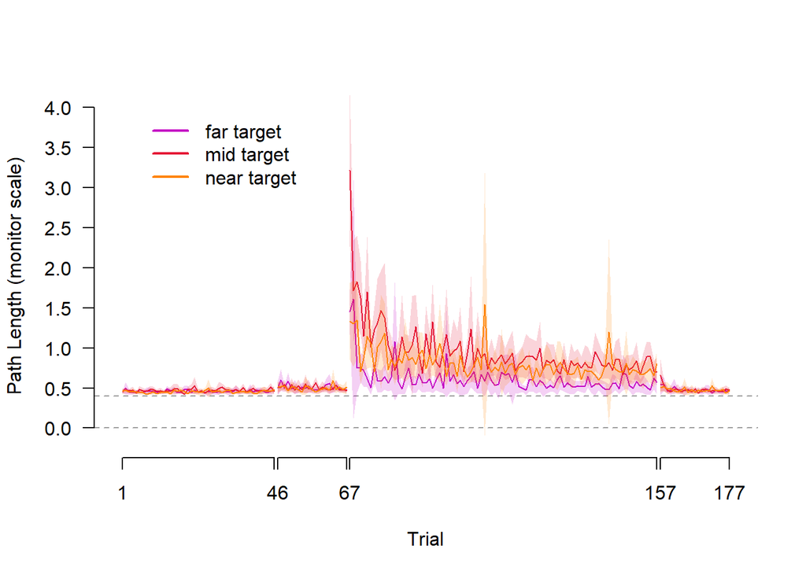

```r
plotCtrlPL()
```

For aligned reaches, we first test for an effect of target or block while participants used either their dominant or non-dominant hand. We conduct a 3x3 (target x block) within-subjects ANOVA for the dominant hand, and conduct the same test for aligned trials using the non-dominant hand.

```r
alignedPLANOVA()
```

```
## Path length during aligned trials across targets and blocks, trained hand:
## $ANOVA
##         Effect DFn DFd          F            p p<.05          ges
## 2        block   2 124 0.70283794 0.4971397670       1.762978e-03
## 3       target   2 124 8.92708745 0.0002387442     * 1.862129e-02
## 4 block:target   4 248 0.02574106 0.9987097892       8.024887e-05
##
## $`Mauchly's Test for Sphericity`
##         Effect         W           p p<.05
## 2        block 0.8325765 0.003740557     *
## 3       target 0.9735067 0.440897694
## 4 block:target 0.7160316 0.016867491     *
##
## $`Sphericity Corrections`
##         Effect       GGe        p[GG] p[GG]<.05      HFe        p[HF] p[HF]<.05
## 2        block 0.8565872 0.4765470227           0.878550 0.4799124260
## 3       target 0.9741905 0.0002758861         * 1.005368 0.0002387442         *
## 4 block:target 0.8696230 0.9972379563           0.927629 0.9980333414
##
## Path length during aligned trials across targets and blocks, untrained hand:
## $ANOVA
##         Effect DFn DFd         F           p p<.05         ges
## 2        block   2 124 5.6321301 0.004558214     * 0.014098260
## 3       target   2 124 0.8258100 0.440273720       0.002335364
## 4 block:target   4 248 0.8487599 0.495490318       0.004837177
##
## $`Mauchly's Test for Sphericity`
##         Effect         W            p p<.05
## 2        block 0.9511044 0.2167500984
## 3       target 0.8534467 0.0079593914     *
## 4 block:target 0.6140091 0.0005428905     *
##
## $`Sphericity Corrections`
##         Effect       GGe      p[GG] p[GG]<.05       HFe       p[HF] p[HF]<.05
## 2        block 0.9533837 0.00524604         * 0.9828590 0.004799835         *
## 3       target 0.8721792 0.42620025           0.8953069 0.428906995
## 4 block:target 0.7953358 0.47432013           0.8433745 0.479759731
```

```r
alignedPLBayesANOVA()
```

```
## Bayes factor analysis
## --------------
## [1] target + participant                        : 201.3168   ±0.57%
## [2] block + participant                         : 0.04556183 ±0.65%
## [3] target + block + participant                : 9.619078   ±1.33%
## [4] target + block + target:block + participant : 0.07813709 ±4.99%
##
## Against denominator:
##   pathlength ~ participant
## ---
## Bayes factor type: BFlinearModel, JZS
##
## Inclusion Bayes Factors (Model Averaged)
##
##              P(prior) P(posterior) Inclusion BF
## participant      1.00         1.00
## target           0.60         1.00       134.55
## block            0.60         0.05        0.032
## block:target     0.20     3.68e-04        0.001
##
## * Compared among: all models
## *    Priors odds: uniform-equalBayes factor analysis
## --------------
## [1] target + participant                        : 0.04364404  ±0.69%
## [2] block + participant                         : 2.613627    ±0.77%
## [3] target + block + participant                : 0.1222466   ±3.91%
## [4] target + block + target:block + participant : 0.003647312 ±2.82%
##
## Against denominator:
##   pathlength ~ participant
## ---
## Bayes factor type: BFlinearModel, JZS
##
## Inclusion Bayes Factors (Model Averaged)
##
##              P(prior) P(posterior) Inclusion BF
## participant      1.00         1.00
## target           0.60         0.04        0.031
## block            0.60         0.72         1.75
## block:target     0.20     9.64e-04        0.004
##
## * Compared among: all models
## *    Priors odds: uniform-equal
```

We find a main effect of target for the trained hand, and a main effect of block for the untrained hand. From the plot, we observe that the path lengths become shorter as aligned reaches progress with the untrained/nondominant hand. Thus, we conduct follow up tests for the main effect of target in the trained hand.

```r
trainedHandPLComparisonsEffSizeTargetEffect()
```

```
##  contrast     estimate      SE df t.ratio p.value
##  Far vs. Mid   0.01020 0.00418 62   2.441  0.0526
##  Far vs. Near -0.00689 0.00373 62  -1.847  0.2087
##  Mid vs. Near -0.01709 0.00428 62  -3.994  0.0005
##
## P value adjustment: bonferroni method for 3 tests
##       contrast etasquared
## 1  Far vs. Mid 0.08765434
## 2 Far vs. Near 0.05213559
## 3 Mid vs. Near 0.20466801
```

```r
trainedHandPLTargetEffectBayesfollowup()
```

```
## Bayesian t-test far vs mid target:
## Bayes factor analysis
## --------------
## [1] Alt., r=0.707 : 0.3993048 ±0.02%
##
## Against denominator:
##   Null, mu1-mu2 = 0
## ---
## Bayes factor type: BFindepSample, JZS
##
## Bayesian t-test far vs near target:
## Bayes factor analysis
## --------------
## [1] Alt., r=0.707 : 0.3074171 ±0.03%
##
## Against denominator:
##   Null, mu1-mu2 = 0
## ---
## Bayes factor type: BFindepSample, JZS
##
## Bayesian t-test mid vs near target:
## Bayes factor analysis
## --------------
## [1] Alt., r=0.707 : 2.019948 ±0.01%
##
## Against denominator:
##   Null, mu1-mu2 = 0
## ---
## Bayes factor type: BFindepSample, JZS
```

The target effect is driven by a difference between middle and near target path lengths.

Next, we can compare the two aligned trials between the trained and untrained hands. We conduct a 3x3x2 (target x block x hand) within-subjects ANOVA.

```r
alignedPLANOVA2Hands()
```

```
## Comparing targets and blocks between trained and untrained hands:
## $ANOVA
##              Effect DFn DFd          F            p p<.05         ges
## 2            target   2 124  0.9370209 3.945495e-01       0.001410317
## 3             block   2 124  3.7850569 2.537435e-02     * 0.004789706
## 4              hand   1  62 32.4894316 3.555892e-07     * 0.046169631
## 5      target:block   4 248  0.8423108 4.994801e-01       0.002308271
## 6       target:hand   2 124  2.3006869 1.044520e-01       0.002855826
## 7        block:hand   2 124  6.3497149 2.369239e-03     * 0.007964748
## 8 target:block:hand   4 248  0.7438230 5.629464e-01       0.001986878
##
## $`Mauchly's Test for Sphericity`
##              Effect         W           p p<.05
## 2            target 0.9230495 0.086968632
## 3             block 0.9607552 0.294909497
## 5      target:block 0.6420409 0.001533283     *
## 6       target:hand 0.8314675 0.003591538     *
## 7        block:hand 0.9117231 0.059678859
## 8 target:block:hand 0.6499961 0.002031332     *
##
## $`Sphericity Corrections`
##              Effect       GGe       p[GG] p[GG]<.05       HFe       p[HF]
## 2            target 0.9285478 0.388839776           0.9560315 0.391099567
## 3             block 0.9622372 0.026958635         * 0.9924332 0.025684081
## 5      target:block 0.8107457 0.479678184           0.8607819 0.485342045
## 6       target:hand 0.8557742 0.113058031           0.8776768 0.111725021
## 7        block:hand 0.9188838 0.003167035         * 0.9456045 0.002878002
## 8 target:block:hand 0.8120525 0.537031797           0.8622598 0.544467437
##   p[HF]<.05
## 2
## 3         *
## 5
## 6
## 7         *
## 8
```

```r
alignedPL2HandsBayesANOVA()
```

```
## Bayes factor analysis
## --------------
## [1] target + participant                                                                               : 0.02489583   ±1.13%
## [2] block + participant                                                                                : 0.2098138    ±0.62%
## [3] target + block + participant                                                                       : 0.005399031  ±1.5%
## [4] target + block + target:block + participant                                                        : 4.631419e-05 ±1.42%
## [5] hand + participant                                                                                 : 5.365413e+12 ±1.13%
## [6] target + hand + participant                                                                        : 146825415458 ±2.27%
## [7] block + hand + participant                                                                         : 1.386181e+12 ±1.67%
## [8] target + block + hand + participant                                                                : 37324945764  ±2.8%
## [9] target + block + target:block + hand + participant                                                 : 380478756    ±6.24%
## [10] target + hand + target:hand + participant                                                         : 18898846498  ±3.31%
## [11] target + block + hand + target:hand + participant                                                 : 4883827289   ±3.13%
## [12] target + block + target:block + hand + target:hand + participant                                  : 45191259     ±2.13%
## [13] block + hand + block:hand + participant                                                           : 5.784045e+12 ±2.69%
## [14] target + block + hand + block:hand + participant                                                  : 148693734784 ±1.86%
## [15] target + block + target:block + hand + block:hand + participant                                   : 1489973152   ±5.26%
## [16] target + block + hand + target:hand + block:hand + participant                                    : 19621895530  ±2.51%
## [17] target + block + target:block + hand + target:hand + block:hand + participant                     : 196806382    ±5.89%
## [18] target + block + target:block + hand + target:hand + block:hand + target:block:hand + participant : 4565993      ±3.74%
##
## Against denominator:
##   pathlength ~ participant
## ---
## Bayes factor type: BFlinearModel, JZS
##
## Inclusion Bayes Factors (Model Averaged)
##
##                   P(prior) P(posterior) Inclusion BF
## participant           1.00         1.00
## target                0.74         0.03        0.011
## block                 0.74         0.57        0.477
## block:target          0.32     1.64e-04     3.55e-04
## hand                  0.74         1.00     3.72e+12
## hand:target           0.32     3.38e-03        0.007
## block:hand            0.32         0.46         1.85
## block:hand:target     0.05     3.54e-07     6.36e-06
##
## * Compared among: all models
## *    Priors odds: uniform-equal
```

We find a main effect of hand.

```r
PLComparisonsHandEffect()
```

```
##
##  Paired t-test
##
## data:  trained$pathlength and untrained$pathlength
## t = -5.7, df = 62, p-value = 1.778e-07
## alternative hypothesis: true mean difference is less than 0
## 95 percent confidence interval:
##         -Inf -0.03286534
## sample estimates:
## mean difference
##     -0.04648238
##
## Bayesian t-test (trained hand vs. untrained hand):
```

```
## t is large; approximation invoked.
## t is large; approximation invoked.
```

```
## Bayes factor analysis
## --------------
## [1] Alt., r=0.707 -Inf<d<0 : 5624467 ±NA%
##
## Against denominator:
##   Alternative, r = 0.707106781186548, mu =/= 0 !(-Inf<d<0)
## ---
## Bayes factor type: BFoneSample, JZS
```

Follow-up tests comparing PLs in the two hands suggest that path lengths were longer for the untrained/ nondominant hand.

We then conducted a 3x3 (target x block) within-subjects ANOVA for path lengths during the mirror reversed trials.

```r
mirrorPLANOVA()
```

```
## $ANOVA
##         Effect DFn DFd         F            p p<.05        ges
## 2       target   2 124 22.848207 3.568117e-09     * 0.06955679
## 3        block   2 124 30.872062 1.316465e-11     * 0.12362195
## 4 target:block   4 248  4.766978 1.010407e-03     * 0.02462987
##
## $`Mauchly's Test for Sphericity`
##         Effect         W            p p<.05
## 2       target 0.9997251 9.916481e-01
## 3        block 0.4613638 5.666666e-11     *
## 4 target:block 0.1788990 2.617593e-18     *
##
## $`Sphericity Corrections`
##         Effect       GGe        p[GG] p[GG]<.05       HFe        p[HF]
## 2       target 0.9997251 3.583854e-09         * 1.0330353 3.568117e-09
## 3        block 0.6499262 2.422326e-08         * 0.6580767 2.032174e-08
## 4 target:block 0.6458999 5.127498e-03         * 0.6764410 4.450701e-03
##   p[HF]<.05
## 2         *
## 3         *
## 4         *
```

```r
mirrorPLBayesANOVA()
```

```
## Bayes factor analysis
## --------------
## [1] target + participant                        : 1632300      ±1.46%
## [2] block + participant                         : 7.21395e+13  ±3.08%
## [3] target + block + participant                : 1.772949e+21 ±1.61%
## [4] target + block + target:block + participant : 8.534793e+21 ±1.5%
##
## Against denominator:
##   pathlength ~ participant
## ---
## Bayes factor type: BFlinearModel, JZS
##
## Inclusion Bayes Factors (Model Averaged)
##
##              P(prior) P(posterior) Inclusion BF
## participant      1.00         1.00
## target           0.60         1.00     9.53e+07
## block            0.60         1.00     4.21e+15
## block:target     0.20         0.83        19.26
##
## * Compared among: all models
## *    Priors odds: uniform-equal
```

We find a significant target by block interaction.

```r
mirrorPLComparisonsEffSize()
```

```
##  contrast                 estimate     SE df t.ratio p.value
##  1st block: Far vs. Mid     0.9583 0.2424 62   3.953  0.0018
##  1st block: Far vs. Near    0.0138 0.2769 62   0.050  1.0000
##  1st block: Mid vs. Near   -0.9444 0.2629 62  -3.592  0.0058
##  2nd block: Far vs. Mid     0.7965 0.1385 62   5.751  <.0001
##  2nd block: Far vs. Near    0.1987 0.0759 62   2.616  0.1003
##  2nd block: Mid vs. Near   -0.5978 0.1319 62  -4.532  0.0002
##  last block: Far vs. Mid    0.2245 0.0249 62   9.002  <.0001
##  last block: Far vs. Near   0.1889 0.0428 62   4.409  0.0004
##  last block: Mid vs. Near  -0.0356 0.0398 62  -0.895  1.0000
##
## P value adjustment: bonferroni method for 9 tests
##                   contrast   etasquared
## 1   1st block: Far vs. Mid 2.013354e-01
## 2  1st block: Far vs. Near 4.009271e-05
## 3  1st block: Mid vs. Near 1.722531e-01
## 4   2nd block: Far vs. Mid 3.478839e-01
## 5  2nd block: Far vs. Near 9.943038e-02
## 6  2nd block: Mid vs. Near 2.487997e-01
## 7  last block: Far vs. Mid 5.665241e-01
## 8 last block: Far vs. Near 2.387150e-01
## 9 last block: Mid vs. Near 1.276537e-02
```

```r
mirrorPLBayesfollowup()
```

```
## FIRST BLOCK:
## Bayesian t-test far vs mid target:
## Bayes factor analysis
## --------------
## [1] Alt., r=0.707 : 7.73993 ±0%
##
## Against denominator:
##   Null, mu1-mu2 = 0
## ---
## Bayes factor type: BFindepSample, JZS
##
## Bayesian t-test far vs near target:
## Bayes factor analysis
## --------------
## [1] Alt., r=0.707 : 0.190372 ±0.04%
##
## Against denominator:
##   Null, mu1-mu2 = 0
## ---
## Bayes factor type: BFindepSample, JZS
##
## Bayesian t-test mid vs near target:
## Bayes factor analysis
## --------------
## [1] Alt., r=0.707 : 57.25084 ±0%
##
## Against denominator:
##   Null, mu1-mu2 = 0
## ---
## Bayes factor type: BFindepSample, JZS
##
## SECOND BLOCK:
## Bayesian t-test far vs mid target:
## Bayes factor analysis
## --------------
## [1] Alt., r=0.707 : 135502.4 ±0%
##
## Against denominator:
##   Null, mu1-mu2 = 0
## ---
```

[output cut: 37 more lines]

```
##
## Against denominator:
##   Null, mu1-mu2 = 0
## ---
## Bayes factor type: BFindepSample, JZS
##
## Bayesian t-test mid vs near target:
## Bayes factor analysis
## --------------
## [1] Alt., r=0.707 : 0.2281068 ±0.03%
##
## Against denominator:
##   Null, mu1-mu2 = 0
## ---
## Bayes factor type: BFindepSample, JZS
```

Follow-up tests show that the far target had shorter path lengths than the middle target across block of trials. The far target also had a shorter path length than the near target during the end of learning. Finally, the near target had shorter path lengths that the middle target for the first two blocks. Taken together, these results suggest that path lengths were shortest for the far target, and longest for the middle target.

For washout trials, we first conduct a 3x2 (target x first and second block) within-subjects ANOVA to investigate effects across target locations.

```r
RAEPLANOVA()
```

```
## Path length during washout trials across targets and blocks, trained hand:
## $ANOVA
##         Effect DFn DFd         F           p p<.05         ges
## 2        block   1  62 7.8792237 0.006675277     * 0.018132704
## 3       target   2 124 0.2796761 0.756504221       0.001280387
## 4 block:target   2 124 0.9761852 0.379621730       0.003187927
##
## $`Mauchly's Test for Sphericity`
##         Effect         W         p p<.05
## 3       target 0.9416049 0.1595865
## 4 block:target 0.9713834 0.4124921
##
## $`Sphericity Corrections`
##         Effect       GGe     p[GG] p[GG]<.05       HFe     p[HF] p[HF]<.05
## 3       target 0.9448268 0.7440495           0.9736109 0.7506531
## 4 block:target 0.9721795 0.3777028           1.0031915 0.3796217
```

```r
RAEPLBayesANOVA()
```

```
## Bayes factor analysis
## --------------
## [1] target + participant                        : 0.03814606 ±0.64%
## [2] block + participant                         : 8.855683   ±0.91%
## [3] target + block + participant                : 0.3415809  ±1.69%
## [4] target + block + target:block + participant : 0.03698915 ±1.79%
##
## Against denominator:
##   pathlength ~ participant
## ---
## Bayes factor type: BFlinearModel, JZS
##
## Inclusion Bayes Factors (Model Averaged)
##
##              P(prior) P(posterior) Inclusion BF
## participant      1.00         1.00
## target           0.60         0.04        0.028
## block            0.60         0.90         5.93
## block:target     0.20     3.60e-03        0.014
##
## * Compared among: all models
## *    Priors odds: uniform-equal
```

We find a main effect of block, which is already evident from the plot.

Next, we conducted a 3x3 (target x block) within-subjects ANOVA, to test for target effects across the aligned trials, first and second blocks of washout trials.

```r
RAEPLTrainedTargetsANOVA()
```

```
## Comparing path length during washout trials with aligned trials across targets and blocks, trained hand:
## $ANOVA
##         Effect DFn DFd         F            p p<.05         ges
## 2        block   2 124 9.4553639 0.0001507041     * 0.031685134
## 3       target   2 124 0.6134957 0.5430899821       0.001977601
## 4 block:target   4 248 0.7343285 0.5693035410       0.003295324
##
## $`Mauchly's Test for Sphericity`
##         Effect         W            p p<.05
## 2        block 0.5648765 2.720076e-08     *
## 3       target 0.9041194 4.622601e-02     *
## 4 block:target 0.3040437 6.547509e-12     *
##
## $`Sphericity Corrections`
##         Effect       GGe        p[GG] p[GG]<.05       HFe        p[HF]
## 2        block 0.6968041 0.0009424686         * 0.7078240 0.0008814147
## 3       target 0.9125082 0.5288205760           0.9387292 0.5332295422
## 4 block:target 0.7209152 0.5277716009           0.7598180 0.5343947151
##   p[HF]<.05
## 2         *
## 3
## 4
```

```r
RAEPLTrainedTargetsBayesANOVA()
```

```
## Bayes factor analysis
## --------------
## [1] target + participant                        : 0.0373721 ±0.8%
## [2] block + participant                         : 1201.024  ±0.66%
## [3] target + block + participant                : 48.4371   ±1.62%
## [4] target + block + target:block + participant : 0.9576557 ±3.1%
##
## Against denominator:
##   pathlength ~ participant
## ---
## Bayes factor type: BFlinearModel, JZS
##
## Inclusion Bayes Factors (Model Averaged)
##
##              P(prior) P(posterior) Inclusion BF
## participant      1.00         1.00
## target           0.60         0.04        0.027
## block            0.60         1.00       803.58
## block:target     0.20     7.65e-04        0.003
##
## * Compared among: all models
## *    Priors odds: uniform-equal
```

We find a main effect of block.

```r
RAEPLTrainedTargetsComparisonsEffSize()
```

```
##  contrast                  estimate     SE df t.ratio p.value
##  Aligned vs. Washout_b1      0.0533 0.0150 62   3.543  0.0023
##  Aligned vs. Washout_b2      0.0127 0.0075 62   1.693  0.2866
##  Washout_b1 vs. Washout_b2  -0.0406 0.0145 62  -2.807  0.0200
##
## P value adjustment: bonferroni method for 3 tests
##                    contrast etasquared
## 1    Aligned vs. Washout_b1 0.16834419
## 2    Aligned vs. Washout_b2 0.04417288
## 3 Washout_b1 vs. Washout_b2 0.11275488
```

```r
RAEPLTrainedTargetsBlockEffectBayesfollowup()
```

```
## Bayesian t-test aligned vs washout block 1:
## Bayes factor analysis
## --------------
## [1] Alt., r=0.707 : 10.49775 ±0%
##
## Against denominator:
##   Null, mu1-mu2 = 0
## ---
## Bayes factor type: BFindepSample, JZS
##
## Bayesian t-test aligned vs washout block 2:
## Bayes factor analysis
## --------------
## [1] Alt., r=0.707 : 0.3643568 ±0.03%
##
## Against denominator:
##   Null, mu1-mu2 = 0
## ---
## Bayes factor type: BFindepSample, JZS
##
## Bayesian t-test washout block 1 vs washout block 2:
## Bayes factor analysis
## --------------
## [1] Alt., r=0.707 : 1.413927 ±0.01%
##
## Against denominator:
##   Null, mu1-mu2 = 0
## ---
## Bayes factor type: BFindepSample, JZS
```

However, follow-up tests show that the block effect is driven by the first block of washout trials having larger path lengths than in block 2 or aligned trials. This is likely due to switching from mirror reversed trials directly to washout trials. Overall, the path length results support results from the analysis with completion time.

## Session 2

In session 2, we tested for retention and generalization across the workspace and hands. As such, the three possible target locations (far, middle, near) were positioned in either quadrant 1 (5°, 45°, or 85° in polar coordinates), quadrant 2 (95°, 135°, or 175° in polar coordinates), or quadrant 4 (275°, 315°, or 355° in polar coordinates), relative to the mirror axis along the vertical midline.

Participants returned on a different day, and immediately performed 21 trials of mirror reversed reaches to quadrant 1 targets using their dominant or trained hand. They then completed 21 trials of perturbed reaches to quadrant 4 targets followed by 21 trials to quadrant 2 targets. To prevent any possible decay in learning, we had them perform another 21 trials of perturbed reaches to quadrant 1 targets. Finally, we instructed them to switch to their non-dominant hand, and perform 21 trials of perturbed reaches to quadrant 1 targets. The session ended with participants completing 21 washout trials with their non-dominant/ untrained hand.

### Performance for the three targets across quadrants

First, we plot a distribution for when participants returned for the second session.

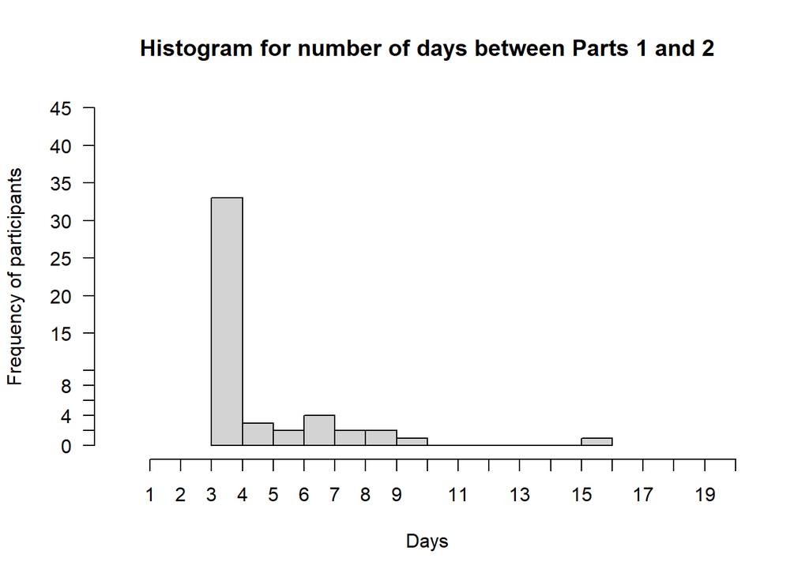

```
## mean: 4.77083333333333 days apart
## sd: 2.52004376298823 days apart
## median: 4 days apart
```

```r
plotCtrlDaysApart()
```

At the start of the session, we observe that participants are able to compensate for the mirror reversed perturbation quickly. This learned performance also seems to transfer well to the targets in other quadrants, as well as to the untrained hand.

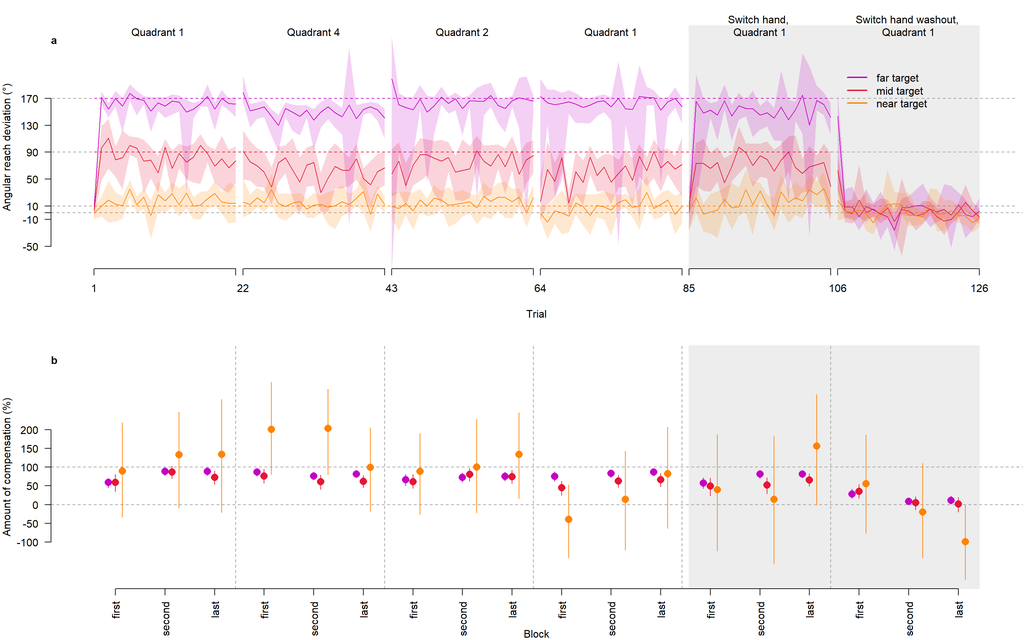

```r
plotBlockedLearningCtrlGen()
```

#### Learned performance

Before testing for retention and generalization, we first tested for target or block effects for reaches within each quadrant. Thus, we conducted 3x3 (target x block) within-subjects ANOVA for quadrants 1, 4, 2, top-up trials in quadrant 1 (Quadrant 1A in tests below), and quadrant 1 after switching hands (Quadrant 1L in tests below).

```r
learningANOVA()
```

```
## Quadrant 1:
## $ANOVA
##         Effect DFn DFd          F         p p<.05          ges
## 2        block   2  94 0.46901815 0.6270723       0.0023303901
## 3       target   2  94 1.24562325 0.2924671       0.0051810200
## 4 block:target   4 188 0.02043224 0.9991793       0.0001970206
##
## $`Mauchly's Test for Sphericity`
##         Effect           W            p p<.05
## 2        block 0.996363137 9.196149e-01
## 3       target 0.090858412 1.102550e-24     *
## 4 block:target 0.003470507 4.926226e-50     *
##
## $`Sphericity Corrections`
##         Effect       GGe     p[GG] p[GG]<.05       HFe     p[HF] p[HF]<.05
## 2        block 0.9963763 0.6263803           1.0404116 0.6270723
## 3       target 0.5237956 0.2721925           0.5253738 0.2723274
## 4 block:target 0.5106443 0.9811571           0.5340814 0.9838602
##
## Quadrant 4:
## $ANOVA
##         Effect DFn DFd         F            p p<.05         ges
## 2        block   2  94 1.0757338 0.3452081283       0.005279960
## 3       target   2  94 8.2511489 0.0004995254     * 0.031337929
## 4 block:target   4 188 0.8965448 0.4671321323       0.008748321
##
## $`Mauchly's Test for Sphericity`
##         Effect           W            p p<.05
## 2        block 0.762965018 1.984296e-03     *
## 3       target 0.101182361 1.310420e-23     *
## 4 block:target 0.002592564 8.119451e-53     *
##
## $`Sphericity Corrections`
##         Effect       GGe       p[GG] p[GG]<.05       HFe      p[HF] p[HF]<.05
## 2        block 0.8083846 0.334486154           0.8329610 0.33608568
## 3       target 0.5266435 0.005327945         * 0.5284141 0.00528064         *
## 4 block:target 0.4258706 0.397584997           0.4402499 0.40048576
##
## Quadrant 2:
## $ANOVA
```

[output cut: 39 more lines]

```
## 2        block   2  94 1.45681140 0.2381893       0.0056150199
## 3       target   2  94 0.08912497 0.9148085       0.0005084902
## 4 block:target   4 188 0.84565030 0.4978731       0.0067348165
##
## $`Mauchly's Test for Sphericity`
##         Effect           W            p p<.05
## 2        block 0.925538099 1.686821e-01
## 3       target 0.068520083 1.674215e-27     *
## 4 block:target 0.002016678 3.234510e-55     *
##
## $`Sphericity Corrections`
##         Effect       GGe     p[GG] p[GG]<.05       HFe     p[HF] p[HF]<.05
## 2        block 0.9306984 0.2388813           0.9675427 0.2385421
## 3       target 0.5177377 0.7754530           0.5189091 0.7760227
## 4 block:target 0.4604347 0.4244841           0.4783369 0.4282104
```

```r
learningBayesANOVA()
```

```
##
## Quadrant 1:
## Bayes factor analysis
## --------------
## [1] target + participant                        : 0.07666177   ±0.95%
## [2] block + participant                         : 0.0414487    ±1.35%
## [3] target + block + participant                : 0.003275059  ±2.06%
## [4] target + block + target:block + participant : 3.847231e-05 ±2.57%
##
## Against denominator:
##   percentcomp ~ participant
## ---
## Bayes factor type: BFlinearModel, JZS
##
## Inclusion Bayes Factors (Model Averaged)
##
##              P(prior) P(posterior) Inclusion BF
## participant      1.00         1.00
## target           0.60         0.07        0.051
## block            0.60         0.04        0.028
## block:target     0.20     3.43e-05     1.37e-04
##
## * Compared among: all models
## *    Priors odds: uniform-equal
## Quadrant 4:
## Bayes factor analysis
## --------------
## [1] target + participant                        : 23.18319   ±8.22%
## [2] block + participant                         : 0.07508972 ±0.78%
## [3] target + block + participant                : 1.607732   ±0.92%
## [4] target + block + target:block + participant : 0.086577   ±1.11%
##
## Against denominator:
##   percentcomp ~ participant
## ---
## Bayes factor type: BFlinearModel, JZS
##
## Inclusion Bayes Factors (Model Averaged)
##
##              P(prior) P(posterior) Inclusion BF
```

[output cut: 61 more lines]

```
## Against denominator:
##   percentcomp ~ participant
## ---
## Bayes factor type: BFlinearModel, JZS
##
## Inclusion Bayes Factors (Model Averaged)
##
##              P(prior) P(posterior) Inclusion BF
## participant      1.00         1.00
## target           0.60         0.03        0.019
## block            0.60         0.08        0.059
## block:target     0.20     8.78e-05     3.51e-04
##
## * Compared among: all models
## *    Priors odds: uniform-equal
```

In all tests, we only find a main effect of target for reaches in quadrant 4.

```r
quadrant4ComparisonsEffSize()
```

```
##  contrast     estimate    SE df t.ratio p.value
##  Far vs. Mid     -15.2  7.12 47  -2.135  0.1139
##  Far vs. Near     83.8 33.60 47   2.495  0.0485
##  Mid vs. Near     99.0 29.81 47   3.322  0.0052
##
## P value adjustment: bonferroni method for 3 tests
##       contrast etasquared
## 1  Far vs. Mid 0.08843739
## 2 Far vs. Near 0.11696547
## 3 Mid vs. Near 0.19013349
```

```r
quadrant4ComparisonsBayesfollowup()
```

```
## Bayesian t-test far vs mid target:
## Bayes factor analysis
## --------------
## [1] Alt., r=0.707 : 1.465255 ±0.01%
##
## Against denominator:
##   Null, mu1-mu2 = 0
## ---
## Bayes factor type: BFindepSample, JZS
##
## Bayesian t-test far vs near target:
## Bayes factor analysis
## --------------
## [1] Alt., r=0.707 : 3.465854 ±0.01%
##
## Against denominator:
##   Null, mu1-mu2 = 0
## ---
## Bayes factor type: BFindepSample, JZS
##
## Bayesian t-test mid vs near target:
## Bayes factor analysis
## --------------
## [1] Alt., r=0.707 : 8.941381 ±0%
##
## Against denominator:
##   Null, mu1-mu2 = 0
## ---
## Bayes factor type: BFindepSample, JZS
```

#### Retention

To quantify retention, we compare the learned performance between the last block of mirror reversed reaches in session 1, with the first block of mirror reversed reaches in session 2.

```r
retentionANOVA()
```

```
## Retention of learned performance, trained hand:
## $ANOVA
##           Effect DFn DFd          F         p p<.05          ges
## 2         target   2  94 0.08686344 0.9168758       0.0007296872
## 3        session   1  47 0.05827637 0.8102914       0.0001645907
## 4 target:session   2  94 0.56768055 0.5687697       0.0029940606
##
## $`Mauchly's Test for Sphericity`
##           Effect         W            p p<.05
## 2         target 0.1045907 2.807604e-23     *
## 4 target:session 0.1126511 1.548507e-22     *
##
## $`Sphericity Corrections`
##           Effect       GGe     p[GG] p[GG]<.05       HFe     p[HF] p[HF]<.05
## 2         target 0.5275905 0.7830619           0.5294252 0.7839292
## 4 target:session 0.5298437 0.4642873           0.5318314 0.4648923
```

```r
retentionBayesANOVA()
```

```
## Retention of learned performance, trained hand:
## Bayes factor analysis
## --------------
## [1] target + participant                            : 0.0404659    ±0.63%
## [2] session + participant                           : 0.1279499    ±0.79%
## [3] target + session + participant                  : 0.005339973  ±1.91%
## [4] target + session + target:session + participant : 0.0005470215 ±1.92%
##
## Against denominator:
##   percentcomp ~ participant
## ---
## Bayes factor type: BFlinearModel, JZS
##
## Inclusion Bayes Factors (Model Averaged)
##
##                P(prior) P(posterior) Inclusion BF
## participant        1.00         1.00
## target             0.60         0.04        0.027
## session            0.60         0.11        0.086
## session:target     0.20     4.66e-04        0.002
##
## * Compared among: all models
## *    Priors odds: uniform-equal
```

#### Generalization across the workspace and hands

To quantify generalization, we compare reaching performance across quadrants. We conduct a 3x3x2 (target x block x quadrant) within-subjects ANOVA to compare the first set of reaches to quadrant 1 with reaches in quadrant 4. We repeat this test but instead compare quadrant 1 with quadrant 2, quadrant 1 and reaches to quadrant 1 after switching hands (Quadrant 1L).

```r
#Quadrant 1 vs Quadrant 4
learningANOVA2Quads(quadrantA= '1', quadrantB = '4')
```

```
##
## Quadrants 1 and 4:
## $ANOVA
##                  Effect DFn DFd         F           p p<.05          ges
## 2                target   2  94 5.8916551 0.003885107     * 0.0146024272
## 3                 block   2  94 0.3048346 0.737971303       0.0008071270
## 4              quadrant   1  47 0.8786223 0.353371233       0.0007741419
## 5          target:block   4 188 0.2784957 0.891631979       0.0015472166
## 6       target:quadrant   2  94 1.2733422 0.284677410       0.0019757918
## 7        block:quadrant   2  94 1.2105113 0.302647911       0.0027893757
## 8 target:block:quadrant   4 188 0.5598059 0.692116899       0.0023264191
##
## $`Mauchly's Test for Sphericity`
##                  Effect           W            p p<.05
## 2                target 0.100746692 1.186611e-23     *
## 3                 block 0.927990833 1.792688e-01
## 5          target:block 0.004529887 1.770413e-47     *
## 6       target:quadrant 0.106500049 4.256431e-23     *
## 7        block:quadrant 0.881173420 5.450194e-02
## 8 target:block:quadrant 0.002467970 2.873020e-53     *
##
## $`Sphericity Corrections`
##                  Effect       GGe      p[GG] p[GG]<.05       HFe      p[HF]
## 2                target 0.5265227 0.01755037         * 0.5282851 0.01745198
## 3                 block 0.9328278 0.72283412           0.9698986 0.73133737
## 5          target:block 0.4789119 0.74812213           0.4987933 0.75701776
## 6       target:quadrant 0.5281225 0.26718582           0.5299933 0.26733147
## 7        block:quadrant 0.8937936 0.29982226           0.9267829 0.30079397
## 8 target:block:quadrant 0.4551332 0.55734524           0.4724800 0.56364957
##   p[HF]<.05
## 2         *
## 3
## 5
## 6
## 7
## 8
```

```r
learningBayesANOVA2Quads(quadrantA= '1', quadrantB = '4')
```

```
## Quadrants 1 and 4:
## Bayes factor analysis
## --------------
## [1] target + participant                                                                                               : 7.579137     ±1.22%
## [2] block + participant                                                                                                : 0.0182335    ±0.53%
## [3] target + block + participant                                                                                       : 0.1422413    ±1.26%
## [4] target + block + target:block + participant                                                                        : 0.0009399772 ±1.44%
## [5] quadrant + participant                                                                                             : 0.1043709    ±1.2%
## [6] target + quadrant + participant                                                                                    : 0.7965627    ±1.93%
## [7] block + quadrant + participant                                                                                     : 0.002064292  ±6.11%
## [8] target + block + quadrant + participant                                                                            : 0.01527335   ±2.52%
## [9] target + block + target:block + quadrant + participant                                                             : 9.875658e-05 ±2.64%
## [10] target + quadrant + target:quadrant + participant                                                                 : 0.04700648   ±3.09%
## [11] target + block + quadrant + target:quadrant + participant                                                         : 0.0008648366 ±2.1%
## [12] target + block + target:block + quadrant + target:quadrant + participant                                          : 5.703527e-06 ±2.45%
## [13] block + quadrant + block:quadrant + participant                                                                   : 0.0001575335 ±1.61%
## [14] target + block + quadrant + block:quadrant + participant                                                          : 0.001247329  ±2.56%
## [15] target + block + target:block + quadrant + block:quadrant + participant                                           : 9.007299e-06 ±7.31%
## [16] target + block + quadrant + target:quadrant + block:quadrant + participant                                        : 6.763997e-05 ±2.27%
## [17] target + block + target:block + quadrant + target:quadrant + block:quadrant + participant                         : 4.969134e-07 ±3.76%
## [18] target + block + target:block + quadrant + target:quadrant + block:quadrant + target:block:quadrant + participant : 1.19053e-08  ±3.49%
##
## Against denominator:
##   percentcomp ~ participant
## ---
## Bayes factor type: BFlinearModel, JZS
##
## Inclusion Bayes Factors (Model Averaged)
##
##                       P(prior) P(posterior) Inclusion BF
## participant               1.00         1.00
## target                    0.74         0.88         2.73
## block                     0.74         0.02        0.007
## block:target              0.32     1.09e-04     2.35e-04
## quadrant                  0.74         0.10        0.040
## quadrant:target           0.32     4.94e-03        0.011
## block:quadrant            0.32     1.53e-04     3.31e-04
## block:quadrant:target     0.05     1.23e-09     2.21e-08
##
## * Compared among: all models
## *    Priors odds: uniform-equal
```

```r
#Quadrant 1 vs Quadrant 2
learningANOVA2Quads(quadrantA= '1', quadrantB = '2')
```

```
##
## Quadrants 1 and 2:
## $ANOVA
##                  Effect DFn DFd          F         p p<.05          ges
## 2                target   2  94 1.84904930 0.1630654       0.0049078740
## 3                 block   2  94 0.82551957 0.4411574       0.0018249315
## 4              quadrant   1  47 0.12966240 0.7203955       0.0001268186
## 5          target:block   4 188 0.09125076 0.9851202       0.0004377990
## 6       target:quadrant   2  94 0.03618134 0.9644788       0.0000685478
## 7        block:quadrant   2  94 0.07373624 0.9289703       0.0001821408
## 8 target:block:quadrant   4 188 0.02912671 0.9983517       0.0001309384
##
## $`Mauchly's Test for Sphericity`
##                  Effect           W            p p<.05
## 2                target 0.057477792 2.941045e-29     *
## 3                 block 0.982121233 6.603852e-01
## 5          target:block 0.003400568 3.283442e-50     *
## 6       target:quadrant 0.104952607 3.039795e-23     *
## 7        block:quadrant 0.985523240 7.150526e-01
## 8 target:block:quadrant 0.007458604 9.745301e-43     *
##
## $`Sphericity Corrections`
##                  Effect       GGe     p[GG] p[GG]<.05       HFe     p[HF]
## 2                target 0.5147946 0.1801961           0.5157696 0.1801824
## 3                 block 0.9824353 0.4393510           1.0249086 0.4411574
## 5          target:block 0.5079766 0.9154345           0.5311072 0.9224177
## 6       target:quadrant 0.5276913 0.8620916           0.5295328 0.8628589
## 7        block:quadrant 0.9857298 0.9268326           1.0285706 0.9289703
## 8 target:block:quadrant 0.5206159 0.9746030           0.5452116 0.9780324
##   p[HF]<.05
## 2
## 3
## 5
## 6
## 7
## 8
```

```r
learningBayesANOVA2Quads(quadrantA= '1', quadrantB = '2')
```

```
## Quadrants 1 and 2:
## Bayes factor analysis
## --------------
## [1] target + participant                                                                                               : 0.1123239    ±0.74%
## [2] block + participant                                                                                                : 0.02952294   ±1.22%
## [3] target + block + participant                                                                                       : 0.003309374  ±1.49%
## [4] target + block + target:block + participant                                                                        : 1.449049e-05 ±2.48%
## [5] quadrant + participant                                                                                             : 0.07900502   ±0.88%
## [6] target + quadrant + participant                                                                                    : 0.008707788  ±1.08%
## [7] block + quadrant + participant                                                                                     : 0.002320951  ±1.75%
## [8] target + block + quadrant + participant                                                                            : 0.0002763725 ±4.03%
## [9] target + block + target:block + quadrant + participant                                                             : 1.16126e-06  ±2.57%
## [10] target + quadrant + target:quadrant + participant                                                                 : 0.0002341103 ±1.9%
## [11] target + block + quadrant + target:quadrant + participant                                                         : 7.819858e-06 ±13.65%
## [12] target + block + target:block + quadrant + target:quadrant + participant                                          : 3.059572e-08 ±4.6%
## [13] block + quadrant + block:quadrant + participant                                                                   : 6.384844e-05 ±1.97%
## [14] target + block + quadrant + block:quadrant + participant                                                          : 7.316947e-06 ±4.3%
## [15] target + block + target:block + quadrant + block:quadrant + participant                                           : 3.207685e-08 ±2.72%
## [16] target + block + quadrant + target:quadrant + block:quadrant + participant                                        : 1.932816e-07 ±5.61%
## [17] target + block + target:block + quadrant + target:quadrant + block:quadrant + participant                         : 8.340987e-10 ±3.49%
## [18] target + block + target:block + quadrant + target:quadrant + block:quadrant + target:block:quadrant + participant : 9.750735e-12 ±3.23%
##
## Against denominator:
##   percentcomp ~ participant
## ---
## Bayes factor type: BFlinearModel, JZS
##
## Inclusion Bayes Factors (Model Averaged)
##
##                       P(prior) P(posterior) Inclusion BF
## participant               1.00         1.00
## target                    0.74         0.10        0.040
## block                     0.74         0.03        0.011
## block:target              0.32     1.27e-05     2.76e-05
## quadrant                  0.74         0.07        0.028
## quadrant:target           0.32     1.96e-04     4.25e-04
## block:quadrant            0.32     5.78e-05     1.25e-04
## block:quadrant:target     0.05     7.89e-12     1.42e-10
##
## * Compared among: all models
## *    Priors odds: uniform-equal
```

```r
#Quadrant 1 vs Switch hands, Quadrant 1
learningANOVA2Quads(quadrantA= '1', quadrantB = '1L')
```

```
##
## Quadrants 1 and 1L:
## $ANOVA
##                  Effect DFn DFd         F         p p<.05         ges
## 2                target   2  94 0.4256363 0.6546068       0.001463417
## 3                 block   2  94 1.1517534 0.3205017       0.002782252
## 4              quadrant   1  47 1.7685407 0.1899809       0.001606810
## 5          target:block   4 188 0.4908462 0.7424620       0.002320116
## 6       target:quadrant   2  94 0.6213553 0.5394075       0.001009166
## 7        block:quadrant   2  94 0.7677213 0.4669568       0.001468688
## 8 target:block:quadrant   4 188 0.4289964 0.7875806       0.001696419
##
## $`Mauchly's Test for Sphericity`
##                  Effect           W            p p<.05
## 2                target 0.067796709 1.311590e-27     *
## 3                 block 0.972897153 5.315443e-01
## 5          target:block 0.002971566 1.699690e-51     *
## 6       target:quadrant 0.094253831 2.563759e-24     *
## 7        block:quadrant 0.902193152 9.373226e-02
## 8 target:block:quadrant 0.002926948 1.219134e-51     *
##
## $`Sphericity Corrections`
##                  Effect       GGe     p[GG] p[GG]<.05       HFe     p[HF]
## 2                target 0.5175439 0.5240269           0.5187023 0.5244626
## 3                 block 0.9736123 0.3196110           1.0151071 0.3205017
## 5          target:block 0.4917545 0.6105808           0.5130509 0.6184553
## 6       target:quadrant 0.5247289 0.4417076           0.5263700 0.4421743
## 7        block:quadrant 0.9109071 0.4561049           0.9456674 0.4604638
## 8 target:block:quadrant 0.4507149 0.6317763           0.4676029 0.6390977
##   p[HF]<.05
## 2
## 3
## 5
## 6
## 7
## 8
```

```r
learningBayesANOVA2Quads(quadrantA= '1', quadrantB = '1L')
```

```
## Quadrants 1 and 1L:
## Bayes factor analysis
## --------------
## [1] target + participant                                                                                               : 0.02501627   ±0.67%
## [2] block + participant                                                                                                : 0.04524388   ±0.94%
## [3] target + block + participant                                                                                       : 0.001163796  ±1.4%
## [4] target + block + target:block + participant                                                                        : 1.05323e-05  ±1.54%
## [5] quadrant + participant                                                                                             : 0.1566518    ±1.33%
## [6] target + quadrant + participant                                                                                    : 0.003853846  ±1.34%
## [7] block + quadrant + participant                                                                                     : 0.006879466  ±1.81%
## [8] target + block + quadrant + participant                                                                            : 0.0001749591 ±2.2%
## [9] target + block + target:block + quadrant + participant                                                             : 1.59183e-06  ±1.57%
## [10] target + quadrant + target:quadrant + participant                                                                 : 0.0001531765 ±2.28%
## [11] target + block + quadrant + target:quadrant + participant                                                         : 7.480727e-06 ±7.19%
## [12] target + block + target:block + quadrant + target:quadrant + participant                                          : 6.552856e-08 ±4.73%
## [13] block + quadrant + block:quadrant + participant                                                                   : 0.0003661906 ±5.42%
## [14] target + block + quadrant + block:quadrant + participant                                                          : 8.666925e-06 ±2.61%
## [15] target + block + target:block + quadrant + block:quadrant + participant                                           : 7.533346e-08 ±1.98%
## [16] target + block + quadrant + target:quadrant + block:quadrant + participant                                        : 3.413374e-07 ±2.79%
## [17] target + block + target:block + quadrant + target:quadrant + block:quadrant + participant                         : 3.290375e-09 ±4.51%
## [18] target + block + target:block + quadrant + target:quadrant + block:quadrant + target:block:quadrant + participant : 6.802282e-11 ±7.36%
##
## Against denominator:
##   percentcomp ~ participant
## ---
## Bayes factor type: BFlinearModel, JZS
##
## Inclusion Bayes Factors (Model Averaged)
##
##                       P(prior) P(posterior) Inclusion BF
## participant               1.00         1.00
## target                    0.74         0.02        0.009
## block                     0.74         0.04        0.016
## block:target              0.32     9.90e-06     2.14e-05
## quadrant                  0.74         0.14        0.056
## quadrant:target           0.32     1.30e-04     2.82e-04
## block:quadrant            0.32     3.03e-04     6.56e-04
## block:quadrant:target     0.05     5.49e-11     9.88e-10
##
## * Compared among: all models
## *    Priors odds: uniform-equal
```

We find no effects of quadrant, suggesting that overall reaching performance did not differ between each comparison of quadrants. This is evidence that participants are able to transfer learning to other target locations and to their untrained hand.

We did find a target effect when comparing quadrant 1 and quadrant 4, which is likely driven by the target effect we observed for the analysis within quadrant 4 above.

```r
Q1and4ComparisonsEffSize()
```

```
##  contrast     estimate    SE df t.ratio p.value
##  Far vs. Mid     -10.7  5.48 47  -1.952  0.1708
##  Far vs. Near     61.7 28.46 47   2.166  0.1061
##  Mid vs. Near     72.4 26.71 47   2.709  0.0281
##
## P value adjustment: bonferroni method for 3 tests
##       contrast etasquared
## 1  Far vs. Mid 0.07497162
## 2 Far vs. Near 0.09079807
## 3 Mid vs. Near 0.13507653
```

```r
Q1and4ComparisonsBayesfollowup()
```

```
## Bayesian t-test far vs mid target:
## Bayes factor analysis
## --------------
## [1] Alt., r=0.707 : 1.004491 ±0.01%
##
## Against denominator:
##   Null, mu1-mu2 = 0
## ---
## Bayes factor type: BFindepSample, JZS
##
## Bayesian t-test far vs near target:
## Bayes factor analysis
## --------------
## [1] Alt., r=0.707 : 1.604116 ±0.01%
##
## Against denominator:
##   Null, mu1-mu2 = 0
## ---
## Bayes factor type: BFindepSample, JZS
##
## Bayesian t-test mid vs near target:
## Bayes factor analysis
## --------------
## [1] Alt., r=0.707 : 3.133569 ±0.01%
##
## Against denominator:
##   Null, mu1-mu2 = 0
## ---
## Bayes factor type: BFindepSample, JZS
```

Follow-up tests confirm that this is the case. The effect is driven by the difference in compensation between middle and near targets, regardless of block or session.

#### Reach aftereffects for the untrained/ nondominant hand

First, we test for target or block effects within washout trials using the nondominant or untrained hand.

```r
washoutLearningANOVA()
```

```
## Quadrant 1W:
## $ANOVA
##         Effect DFn DFd          F            p p<.05         ges
## 2        block   2  94 15.1220397 2.023257e-06     * 0.042833644
## 3       target   2  94  3.5808510 3.171401e-02     * 0.017107267
## 4 block:target   4 188  0.8966133 4.670917e-01       0.008680658
##
## $`Mauchly's Test for Sphericity`
##         Effect         W          p p<.05
## 2        block 0.9057849 0.10270157
## 3       target 0.8426683 0.01950308     *
## 4 block:target 0.7970306 0.32682005
##
## $`Sphericity Corrections`
##         Effect       GGe        p[GG] p[GG]<.05       HFe        p[HF]
## 2        block 0.9138971 4.800909e-06         * 0.9489699 3.375679e-06
## 3       target 0.8640565 3.856491e-02         * 0.8940364 3.693677e-02
## 4 block:target 0.8950415 4.585455e-01           0.9779399 4.653805e-01
##   p[HF]<.05
## 2         *
## 3         *
## 4
```

```r
washoutLearningBayesANOVA()
```

```
## Quadrant 1W:
## Bayes factor analysis
## --------------
## [1] target + participant                        : 0.9495502 ±0.73%
## [2] block + participant                         : 346.0925  ±1.13%
## [3] target + block + participant                : 387.6711  ±1.15%
## [4] target + block + target:block + participant : 22.04335  ±2.22%
##
## Against denominator:
##   angdev ~ participant
## ---
## Bayes factor type: BFlinearModel, JZS
##
## Inclusion Bayes Factors (Model Averaged)
##
##              P(prior) P(posterior) Inclusion BF
## participant      1.00         1.00
## target           0.60         0.54        0.789
## block            0.60         1.00       258.46
## block:target     0.20         0.03        0.120
##
## * Compared among: all models
## *    Priors odds: uniform-equal
```

We find main effects of block and target, but no interaction. In the Bayesian test, we only find the effect of block.

```r
washoutComparisonsEffSize()
```

```
##  contrast            estimate   SE df t.ratio p.value
##  block 1 vs. block 2   -22.43 4.82 47  -4.656  0.0001
##  block 1 vs. block 3   -25.00 5.69 47  -4.394  0.0002
##  block 2 vs. block 3    -2.57 4.41 47  -0.584  1.0000
##
## P value adjustment: bonferroni method for 3 tests
##              contrast  etasquared
## 1 block 1 vs. block 2 0.315654642
## 2 block 1 vs. block 3 0.291160194
## 3 block 2 vs. block 3 0.007194419
```

```r
washoutComparisonsBayesfollowup()
```

```
## Bayesian t-test block 1 vs block 2:
## Bayes factor analysis
## --------------
## [1] Alt., r=0.707 : 36.5822 ±0%
##
## Against denominator:
##   Null, mu1-mu2 = 0
## ---
## Bayes factor type: BFindepSample, JZS
##
## Bayesian t-test block 1 vs last block:
## Bayes factor analysis
## --------------
## [1] Alt., r=0.707 : 90.75674 ±0%
##
## Against denominator:
##   Null, mu1-mu2 = 0
## ---
## Bayes factor type: BFindepSample, JZS
##
## Bayesian t-test block 2 vs last block:
## Bayes factor analysis
## --------------
## [1] Alt., r=0.707 : 0.2393834 ±0.02%
##
## Against denominator:
##   Null, mu1-mu2 = 0
## ---
## Bayes factor type: BFindepSample, JZS
```

Follow-up tests show that the effect of block is driven by the difference of the first block of washout trials with the other blocks. This confirms what we see in the plot, where initially participants are compensating in the first washout trial. However, this is likely due to task switching rather than aftereffects, as participants were not instructed that the perturbation has been turned off.

```r
washoutTargetEffectComparisonsEffSize()
```

```
##  contrast     estimate   SE df t.ratio p.value
##  Far vs. Mid      4.42 7.50 47   0.589  1.0000
##  Far vs. Near   -12.14 6.21 47  -1.956  0.1693
##  Mid vs. Near   -16.56 5.33 47  -3.108  0.0096
##
## P value adjustment: bonferroni method for 3 tests
##       contrast  etasquared
## 1  Far vs. Mid 0.007324856
## 2 Far vs. Near 0.075266800
## 3 Mid vs. Near 0.170452381
```

```r
washoutTargetEffectComparisonsBayesfollowup()
```

```
## Bayesian t-test far vs mid target:
## Bayes factor analysis
## --------------
## [1] Alt., r=0.707 : 0.2530544 ±0.02%
##
## Against denominator:
##   Null, mu1-mu2 = 0
## ---
## Bayes factor type: BFindepSample, JZS
##
## Bayesian t-test far vs near target:
## Bayes factor analysis
## --------------
## [1] Alt., r=0.707 : 0.7944837 ±0.01%
##
## Against denominator:
##   Null, mu1-mu2 = 0
## ---
## Bayes factor type: BFindepSample, JZS
##
## Bayesian t-test mid vs near target:
## Bayes factor analysis
## --------------
## [1] Alt., r=0.707 : 3.549782 ±0.01%
##
## Against denominator:
##   Null, mu1-mu2 = 0
## ---
## Bayes factor type: BFindepSample, JZS
```

Follow-up tests on the target effect show that the middle target differs from the near target.

To test for reach aftereffects, we can compare reaching performance between perturbed reaches with the nondominant hand (Quadrant 1L) and washout trials (Quadrant 1W). We conduct a 3x3x2 (target x block x quadrant) within-subjects ANOVA.

```r
learningANOVA2Quads(quadrantA='1L', quadrantB='1W')
```

```
##
## Quadrants 1L and 1W:
## $ANOVA
##                  Effect DFn DFd          F           p p<.05          ges
## 2                target   2  94  0.2121945 0.809193762       0.0009492916
## 3                 block   2  94  0.5591720 0.573571982       0.0008790317
## 4              quadrant   1  47 10.3977196 0.002297113     * 0.0112591076
## 5          target:block   4 188  0.3227002 0.862526463       0.0010402147
## 6       target:quadrant   2  94  0.6193692 0.540465967       0.0010870928
## 7        block:quadrant   2  94  3.6627790 0.029391107     * 0.0073364691
## 8 target:block:quadrant   4 188  1.5835445 0.180365277       0.0069801660
##
## $`Mauchly's Test for Sphericity`
##                  Effect           W            p p<.05
## 2                target 0.076882147 2.365846e-26     *
## 3                 block 0.930398794 1.902787e-01
## 5          target:block 0.007872065 3.168663e-42     *
## 6       target:quadrant 0.079828186 5.618158e-26     *
## 7        block:quadrant 0.936877156 2.232035e-01
## 8 target:block:quadrant 0.002004223 2.954314e-55     *
##
## $`Sphericity Corrections`
##                  Effect       GGe      p[GG] p[GG]<.05       HFe      p[HF]
## 2                target 0.5199889 0.65676290           0.5213111 0.65738333
## 3                 block 0.9349279 0.56219811           0.9722224 0.56880561
## 5          target:block 0.4795409 0.71597892           0.4994908 0.72477079
## 6       target:quadrant 0.5207867 0.44132898           0.5221624 0.44172426
## 7        block:quadrant 0.9406251 0.03212481         * 0.9785290 0.03035145
## 8 target:block:quadrant 0.4835486 0.21146933           0.5039371 0.21047612
##   p[HF]<.05
## 2
## 3
## 5
## 6
## 7         *
## 8
```

```r
learningBayesANOVA2Quads(quadrantA='1L', quadrantB='1W')
```

```
## Quadrants 1L and 1W:
## Bayes factor analysis
## --------------
## [1] target + participant                                                                                               : 0.02031592   ±1.88%
## [2] block + participant                                                                                                : 0.01931165   ±0.59%
## [3] target + block + participant                                                                                       : 0.0003908362 ±1.22%
## [4] target + block + target:block + participant                                                                        : 2.141266e-06 ±1.38%
## [5] quadrant + participant                                                                                             : 12.84214     ±1.03%
## [6] target + quadrant + participant                                                                                    : 0.264237     ±1.69%
## [7] block + quadrant + participant                                                                                     : 0.2594011    ±2.79%
## [8] target + block + quadrant + participant                                                                            : 0.005292721  ±5.39%
## [9] target + block + target:block + quadrant + participant                                                             : 2.974227e-05 ±6.43%
## [10] target + quadrant + target:quadrant + participant                                                                 : 0.01115408   ±2.79%
## [11] target + block + quadrant + target:quadrant + participant                                                         : 0.0002214419 ±3.59%
## [12] target + block + target:block + quadrant + target:quadrant + participant                                          : 1.184023e-06 ±3.48%
## [13] block + quadrant + block:quadrant + participant                                                                   : 0.1589295    ±1.92%
## [14] target + block + quadrant + block:quadrant + participant                                                          : 0.005205711  ±35.5%
## [15] target + block + target:block + quadrant + block:quadrant + participant                                           : 1.772413e-05 ±2.29%
## [16] target + block + quadrant + target:quadrant + block:quadrant + participant                                        : 0.0001361365 ±2.8%
## [17] target + block + target:block + quadrant + target:quadrant + block:quadrant + participant                         : 7.382137e-07 ±3.44%
## [18] target + block + target:block + quadrant + target:quadrant + block:quadrant + target:block:quadrant + participant : 1.089648e-07 ±2.9%
##
## Against denominator:
##   percentcomp ~ participant
## ---
## Bayes factor type: BFlinearModel, JZS
##
## Inclusion Bayes Factors (Model Averaged)
##
##                       P(prior) P(posterior) Inclusion BF
## participant               1.00         1.00
## target                    0.74         0.02        0.008
## block                     0.74         0.03        0.011
## block:target              0.32     3.54e-06     7.67e-06
## quadrant                  0.74         0.93         4.65
## quadrant:target           0.32     7.89e-04        0.002
## block:quadrant            0.32         0.01        0.025
## block:quadrant:target     0.05     7.47e-09     1.34e-07
##
## * Compared among: all models
## *    Priors odds: uniform-equal
```

We find a main effect of quadrant and a block by quadrant interaction in the frequentist test, but only find the main effect of quadrant in the Bayesian test. The main effect of quadrant is seen in the plot, where washout trials are near zero in compensation.

```r
Q1Land1WComparisonsEffSize()
```

```
##  contrast                    estimate   SE df t.ratio p.value
##  Untrained_B3 vs. Washout_B1    -60.9 32.5 47  -1.873  0.2019
##  Untrained_B3 vs. Washout_B2   -101.9 29.4 47  -3.461  0.0035
##  Untrained_B3 vs. Washout_B3   -129.2 28.7 47  -4.507  0.0001
##
## P value adjustment: bonferroni method for 3 tests
##                      contrast etasquared
## 1 Untrained_B3 vs. Washout_B1 0.06944924
## 2 Untrained_B3 vs. Washout_B2 0.20309709
## 3 Untrained_B3 vs. Washout_B3 0.30177830
```

```r
Q1Land1WComparisonsBayesfollowup()
```

```
## Bayesian t-test Untrained last block vs Washout block 1:
## Bayes factor analysis
## --------------
## [1] Alt., r=0.707 : 0.7893392 ±0.01%
##
## Against denominator:
##   Null, mu1-mu2 = 0
## ---
## Bayes factor type: BFindepSample, JZS
##
## Bayesian t-test Untrained last block vs Washout block 2:
## Bayes factor analysis
## --------------
## [1] Alt., r=0.707 : 8.568513 ±0%
##
## Against denominator:
##   Null, mu1-mu2 = 0
## ---
## Bayes factor type: BFindepSample, JZS
##
## Bayesian t-test Untrained last block vs Washout last block:
## Bayes factor analysis
## --------------
## [1] Alt., r=0.707 : 242.7726 ±0%
##
## Against denominator:
##   Null, mu1-mu2 = 0
## ---
## Bayes factor type: BFindepSample, JZS
```

Follow-up tests on the block by quadrant interaction show that the last block of mirror reversed training differs from the second and last blocks of washout trials. The lack of a difference between the first washout block from the training block is likely due to task switching rather than aftereffects, as participants were not instructed that the perturbation has been turned off.

Finally, we compare the washout trials with the aligned baseline trials using the nondominant hand from the first session. We conduct a 3x3x2 (target x block x session) within-subjects ANOVA.

```r
RAEUntrainedHandANOVA()
```

```
## Comparing angular reach deviations during washout trials with aligned trials across targets and blocks, trained hand:
## $ANOVA
##                 Effect DFn DFd          F            p p<.05         ges
## 2                block   2  94 15.7677651 1.244446e-06     * 0.022927060
## 3               target   2  94  1.5553541 2.164983e-01       0.002820846
## 4              session   1  47  0.4072721 5.264547e-01       0.001023962
## 5         block:target   4 188  0.6579821 6.219550e-01       0.003012623
## 6        block:session   2  94  3.3679176 3.866887e-02     * 0.005469397
## 7       target:session   2  94  2.2674716 1.092110e-01       0.007782668
## 8 block:target:session   4 188  0.9187853 4.541233e-01       0.004281288
##
## $`Mauchly's Test for Sphericity`
##                 Effect         W           p p<.05
## 2                block 0.7877256 0.004136416     *
## 3               target 0.9822852 0.662925419
## 5         block:target 0.5634645 0.002017964     *
## 6        block:session 0.9972799 0.939274660
## 7       target:session 0.9304575 0.190555106
## 8 block:target:session 0.8508408 0.602462907
##
## $`Sphericity Corrections`
##                 Effect       GGe        p[GG] p[GG]<.05       HFe        p[HF]
## 2                block 0.8248958 7.831655e-06         * 0.8510434 5.947292e-06
## 3               target 0.9825935 2.168773e-01           1.0250845 2.164983e-01
## 5         block:target 0.7478645 5.788274e-01           0.8043323 5.895535e-01
## 6        block:session 0.9972873 3.880391e-02         * 1.0414253 3.866887e-02
## 7       target:session 0.9349792 1.130313e-01           0.9722792 1.108290e-01
## 8 block:target:session 0.9201433 4.482822e-01           1.0080207 4.541233e-01
##   p[HF]<.05
## 2         *
## 3
## 5
## 6         *
## 7
## 8
```

```r
RAEUntrainedHandBayesANOVA()
```

```
## Comparing angular reach deviations during washout trials with aligned trials across targets and blocks, trained hand:
## Bayes factor analysis
## --------------
## [1] target + participant                                                                                           : 0.04161453   ±0.61%
## [2] block + participant                                                                                            : 210.6934     ±0.57%
## [3] target + block + participant                                                                                   : 9.264115     ±1.14%
## [4] target + block + target:block + participant                                                                    : 0.1021217    ±1.14%
## [5] session + participant                                                                                          : 0.1148461    ±1.13%
## [6] target + session + participant                                                                                 : 0.004907006  ±2.63%
## [7] block + session + participant                                                                                  : 24.59736     ±2.02%
## [8] target + block + session + participant                                                                         : 1.102152     ±2.18%
## [9] target + block + target:block + session + participant                                                          : 0.01302529   ±7.99%
## [10] target + session + target:session + participant                                                               : 0.002784751  ±1.56%
## [11] target + block + session + target:session + participant                                                       : 0.7215466    ±5.39%
## [12] target + block + target:block + session + target:session + participant                                        : 0.007740219  ±2.37%
## [13] block + session + block:session + participant                                                                 : 5.853726     ±1.79%
## [14] target + block + session + block:session + participant                                                        : 0.3013051    ±16.01%
## [15] target + block + target:block + session + block:session + participant                                         : 0.003205338  ±10.9%
## [16] target + block + session + target:session + block:session + participant                                       : 0.1801126    ±12.6%
## [17] target + block + target:block + session + target:session + block:session + participant                        : 0.001951474  ±8.25%
## [18] target + block + target:block + session + target:session + block:session + target:block:session + participant : 0.0001001657 ±8.65%
##
## Against denominator:
##   angdev ~ participant
## ---
## Bayes factor type: BFlinearModel, JZS
##
## Inclusion Bayes Factors (Model Averaged)
##
##                      P(prior) P(posterior) Inclusion BF
## participant              1.00         1.00
## target                   0.74         0.05        0.017
## block                    0.74         1.00        77.57
## block:target             0.32     5.04e-04        0.001
## session                  0.74         0.13        0.053
## session:target           0.32     3.60e-03        0.008
## block:session            0.32         0.02        0.055
## block:session:target     0.05     3.94e-07     7.10e-06
##
## * Compared among: all models
## *    Priors odds: uniform-equal
```

We find a main effect of block and a block by session interaction in the frequentist test, but only a main effect of block in the Bayesian test. We look into the interaction further.

```r
untrainedHandSessionComparisonsEffSize()
```

```
##  contrast                   estimate   SE df t.ratio p.value
##  Baseline_B1 vs. Washout_B1   13.418 7.33 47   1.831  0.2940
##  Baseline_B2 vs. Washout_B2   -0.649 5.42 47  -0.120  1.0000
##  Baseline_B3 vs. Washout_B3   -3.277 6.21 47  -0.528  1.0000
##  Baseline_B3 vs. Washout_B1   21.722 8.47 47   2.564  0.0544
##
## P value adjustment: bonferroni method for 4 tests
##                     contrast   etasquared
## 1 Baseline_B1 vs. Washout_B1 0.0665584359
## 2 Baseline_B2 vs. Washout_B2 0.0003052035
## 3 Baseline_B3 vs. Washout_B3 0.0058888713
## 4 Baseline_B3 vs. Washout_B1 0.1227421759
```

```r
untrainedHandSessionComparisonsBayesfollowup()
```

```
## Bayesian t-test Untrained block 1 vs Washout block 1:
## Bayes factor analysis
## --------------
## [1] Alt., r=0.707 : 1.377666 ±0.01%
##
## Against denominator:
##   Null, mu1-mu2 = 0
## ---
## Bayes factor type: BFindepSample, JZS
##
## Bayesian t-test Untrained block 2 vs Washout block 2:
## Bayes factor analysis
## --------------
## [1] Alt., r=0.707 : 0.21636 ±0.02%
##
## Against denominator:
##   Null, mu1-mu2 = 0
## ---
## Bayes factor type: BFindepSample, JZS
##
## Bayesian t-test Untrained last block vs Washout last block:
## Bayes factor analysis
## --------------
## [1] Alt., r=0.707 : 0.2479524 ±0.02%
##
## Against denominator:
##   Null, mu1-mu2 = 0
## ---
## Bayes factor type: BFindepSample, JZS
##
## Bayesian t-test Untrained last block vs Washout block 1:
## Bayes factor analysis
## --------------
## [1] Alt., r=0.707 : 14.91385 ±0%
##
## Against denominator:
##   Null, mu1-mu2 = 0
## ---
## Bayes factor type: BFindepSample, JZS
```

We find no significant effects, but Bayesian follow-up tests show that the effect is driven by a difference between the last block of aligned reaches and the first block of washout trials. Again, this is likely due to higher compensation percentages during the first washout trial. Overall, the data suggest that we do not observe reach aftereffects, given that the compensation percentages ion the first block immediately go back down to zero.

### Movement analysis

We then repeat the same set of tests but instead use completion time and path length as the dependent variables.

#### Completion time

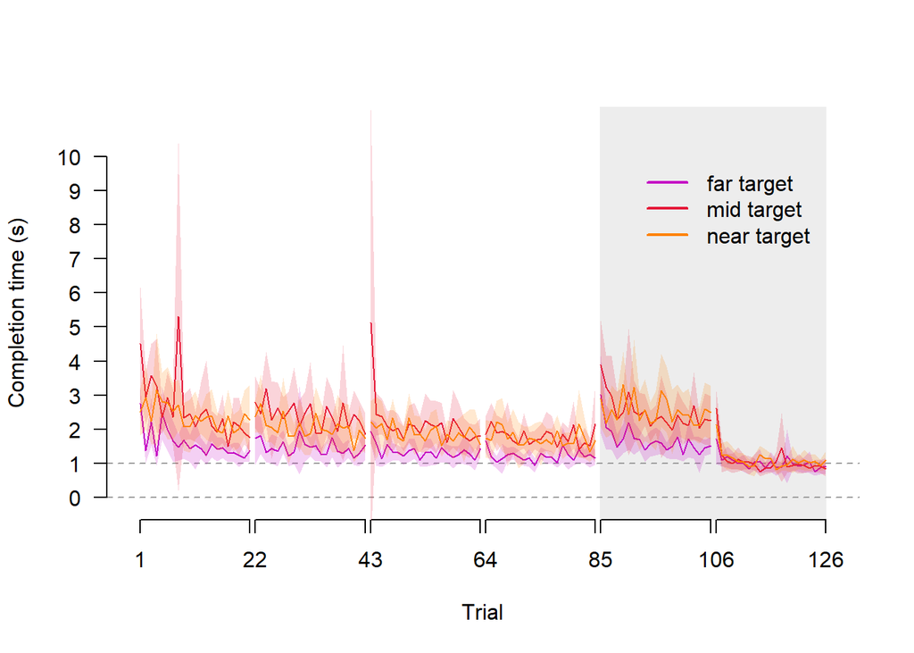

```r
plotCtrlGenMT()
```

##### Learned performance

We first tested for target or block effects for completion time within each quadrant. Thus, we conducted 3x3 (target x block) within-subjects ANOVA for quadrants 1, 4, 2, top-up trials in quadrant 1 (Quadrant 1A in tests below), quadrant 1 after switching hands (Quadrant 1L in tests below), and washout (Quadrant 1W).

```r
movementtimeANOVA()
```

```
## Quadrant 1:
## $ANOVA
##         Effect DFn DFd         F            p p<.05        ges
## 2        block   2  94 29.988308 8.445684e-11     * 0.07926953
## 3       target   2  94 22.691070 9.104875e-09     * 0.07753893
## 4 block:target   4 188  6.768633 4.128631e-05     * 0.02684214
##
## $`Mauchly's Test for Sphericity`
##         Effect         W            p p<.05
## 2        block 0.8705848 0.0412718912     *
## 3       target 0.9655023 0.4459907989
## 4 block:target 0.4856140 0.0001459336     *
##
## $`Sphericity Corrections`
##         Effect       GGe        p[GG] p[GG]<.05       HFe        p[HF]
## 2        block 0.8854139 8.059114e-10         * 0.9175465 4.279397e-10
## 3       target 0.9666527 1.509580e-08         * 1.0073809 9.104875e-09
## 4 block:target 0.7468240 2.751544e-04         * 0.8031216 1.801157e-04
##   p[HF]<.05
## 2         *
## 3         *
## 4         *
##
## Quadrant 4:
## $ANOVA
##         Effect DFn DFd         F            p p<.05         ges
## 2        block   2  94 16.489051 7.273679e-07     * 0.039070346
## 3       target   2  94 26.787957 6.212716e-10     * 0.116236200
## 4 block:target   4 188  1.207168 3.092103e-01       0.004833261
##
## $`Mauchly's Test for Sphericity`
##         Effect         W            p p<.05
## 2        block 0.9357585 0.2171533270
## 3       target 0.9327692 0.2017466183
## 4 block:target 0.4761912 0.0001021447     *
##
## $`Sphericity Corrections`
##         Effect       GGe        p[GG] p[GG]<.05       HFe        p[HF]
## 2        block 0.9396363 1.412572e-06         * 0.9774342 9.321046e-07
## 3       target 0.9370044 1.900460e-09         * 0.9745207 9.763744e-10
```

[output cut: 78 more lines]

```
## $`Mauchly's Test for Sphericity`
##         Effect         W            p p<.05
## 2        block 0.8843819 5.925380e-02
## 3       target 0.7321301 7.682983e-04     *
## 4 block:target 0.1103566 1.652471e-17     *
##
## $`Sphericity Corrections`
##         Effect       GGe        p[GG] p[GG]<.05       HFe        p[HF]
## 2        block 0.8963641 1.057847e-19         * 0.9296176 2.423986e-20
## 3       target 0.7887245 6.001518e-03         * 0.8114642 5.550609e-03
## 4 block:target 0.5059106 8.068637e-03         * 0.5288047 7.190475e-03
##   p[HF]<.05
## 2         *
## 3         *
## 4         *
```

```r
movementtimeBayesANOVA()
```

```
## Quadrant 1:
## Bayes factor analysis
## --------------
## [1] target + participant                        : 382839222    ±2.46%
## [2] block + participant                         : 680310993    ±0.63%
## [3] target + block + participant                : 8.199984e+18 ±1.56%
## [4] target + block + target:block + participant : 3.652149e+20 ±1.49%
##
## Against denominator:
##   movementtime ~ participant
## ---
## Bayes factor type: BFlinearModel, JZS
##
## Inclusion Bayes Factors (Model Averaged)
##
##              P(prior) P(posterior) Inclusion BF
## participant      1.00         1.00
## target           0.60         1.00     3.66e+11
## block            0.60         1.00     6.50e+11
## block:target     0.20         0.98       178.15
##
## * Compared among: all models
## *    Priors odds: uniform-equalQuadrant 4:
## Bayes factor analysis
## --------------
## [1] target + participant                        : 4.85182e+14  ±0.93%
## [2] block + participant                         : 1054.075     ±0.81%
## [3] target + block + participant                : 5.76631e+18  ±1%
## [4] target + block + target:block + participant : 2.450407e+17 ±1.4%
##
## Against denominator:
##   movementtime ~ participant
## ---
## Bayes factor type: BFlinearModel, JZS
##
## Inclusion Bayes Factors (Model Averaged)
##
##              P(prior) P(posterior) Inclusion BF
## participant      1.00         1.00
## target           0.60         1.00     3.80e+15
```

[output cut: 78 more lines]

```
## Against denominator:
##   movementtime ~ participant
## ---
## Bayes factor type: BFlinearModel, JZS
##
## Inclusion Bayes Factors (Model Averaged)
##
##              P(prior) P(posterior) Inclusion BF
## participant      1.00         1.00
## target           0.60         1.00       835.85
## block            0.60         1.00     3.44e+19
## block:target     0.20         0.99       317.15
##
## * Compared among: all models
## *    Priors odds: uniform-equal
```

In quadrant 1, we find a significant target x block interaction. We know from the plot that completion time decreases across blocks. Thus, it is more interesting to test for target differences across the blocks of trials.

```r
quadrant1MTComparisonsEffSize()
```

```
##  contrast                 estimate    SE df t.ratio p.value
##  1st block: Far vs. Mid     1.4475 0.311 47   4.652  0.0002
##  1st block: Far vs. Near    0.4043 0.178 47   2.271  0.2499
##  1st block: Mid vs. Near   -1.0432 0.294 47  -3.552  0.0079
##  2nd block: Far vs. Mid     0.9987 0.194 47   5.159  <.0001
##  2nd block: Far vs. Near    1.0510 0.252 47   4.165  0.0012
##  2nd block: Mid vs. Near    0.0522 0.291 47   0.179  1.0000
##  last block: Far vs. Mid    0.5965 0.105 47   5.689  <.0001
##  last block: Far vs. Near   0.9546 0.186 47   5.140  <.0001
##  last block: Mid vs. Near   0.3581 0.176 47   2.034  0.4284
##
## P value adjustment: bonferroni method for 9 tests
##                   contrast   etasquared
## 1   1st block: Far vs. Mid 0.3152674083
## 2  1st block: Far vs. Near 0.0988854403
## 3  1st block: Mid vs. Near 0.2116270196
## 4   2nd block: Far vs. Mid 0.3615263646
## 5  2nd block: Far vs. Near 0.2695574551
## 6  2nd block: Mid vs. Near 0.0006849891
## 7  last block: Far vs. Mid 0.4077606145
## 8 last block: Far vs. Near 0.3598773765
## 9 last block: Mid vs. Near 0.0809123753
```

```r
quadrant1MTComparisonsBayesfollowup()
```

```
## Bayesian t-test block 1 far vs mid target:
## Bayes factor analysis
## --------------
## [1] Alt., r=0.707 : 205.2714 ±0%
##
## Against denominator:
##   Null, mu1-mu2 = 0
## ---
## Bayes factor type: BFindepSample, JZS
##
## Bayesian t-test block 1 far vs near target:
## Bayes factor analysis
## --------------
## [1] Alt., r=0.707 : 0.5159219 ±0.02%
##
## Against denominator:
##   Null, mu1-mu2 = 0
## ---
## Bayes factor type: BFindepSample, JZS
##
## Bayesian t-test  block 1 mid vs near target:
## Bayes factor analysis
## --------------
## [1] Alt., r=0.707 : 4.409246 ±0.01%
##
## Against denominator:
##   Null, mu1-mu2 = 0
## ---
## Bayes factor type: BFindepSample, JZS
##
## Bayesian t-test block 2 far vs mid target:
## Bayes factor analysis
## --------------
## [1] Alt., r=0.707 : 20.65155 ±0%
##
## Against denominator:
##   Null, mu1-mu2 = 0
## ---
## Bayes factor type: BFindepSample, JZS
##
```

[output cut: 34 more lines]

```
##
## Against denominator:
##   Null, mu1-mu2 = 0
## ---
## Bayes factor type: BFindepSample, JZS
##
## Bayesian t-test last block mid vs near target:
## Bayes factor analysis
## --------------
## [1] Alt., r=0.707 : 0.6495352 ±0.02%
##
## Against denominator:
##   Null, mu1-mu2 = 0
## ---
## Bayes factor type: BFindepSample, JZS
```

Follow-up tests show that the completion time for the far target is faster compared to the middle target in all blocks, and faster compared to the near target in the second and last blocks. Completion time was also faster for the near target compared to the middle target in the first block. This suggests that movement initiation and execution was fastest for the far target and slowest for the middle target.

For quadrants 4, 2 and top-up trials to quadrant 1 (Quadrant 1A), we observe main effects of target. We also observe main effects of block for quadrant 4 and 2, but this is seen with the decrease of completion time from the plot.

```r
#quadrant 4
quadrant4MTComparisonsEffSizeTargetEffect()
```

```
##  contrast     estimate    SE df t.ratio p.value
##  Far vs. Mid     1.021 0.151 47   6.752  <.0001
##  Far vs. Near    0.649 0.122 47   5.337  <.0001
##  Mid vs. Near   -0.372 0.149 47  -2.500  0.0479
##
## P value adjustment: bonferroni method for 3 tests
##       contrast etasquared
## 1  Far vs. Mid  0.4924049
## 2 Far vs. Near  0.3773268
## 3 Mid vs. Near  0.1173990
```

```r
quadrant4MTComparisonsTargetEffectBayesfollowup()
```

```
## Bayesian t-test far vs mid target:
## Bayes factor analysis
## --------------
## [1] Alt., r=0.707 : 7582.645 ±0%
##
## Against denominator:
##   Null, mu1-mu2 = 0
## ---
## Bayes factor type: BFindepSample, JZS
##
## Bayesian t-test far vs near target:
## Bayes factor analysis
## --------------
## [1] Alt., r=0.707 : 117.5709 ±0%
##
## Against denominator:
##   Null, mu1-mu2 = 0
## ---
## Bayes factor type: BFindepSample, JZS
##
## Bayesian t-test mid vs near target:
## Bayes factor analysis
## --------------
## [1] Alt., r=0.707 : 0.7023399 ±0.02%
##
## Against denominator:
##   Null, mu1-mu2 = 0
## ---
## Bayes factor type: BFindepSample, JZS
```

```r
#quadrant 2
quadrant2MTComparisonsEffSizeTargetEffect()
```

```
##  contrast     estimate    SE df t.ratio p.value
##  Far vs. Mid     0.857 0.246 47   3.487  0.0032
##  Far vs. Near    0.577 0.111 47   5.195  <.0001
##  Mid vs. Near   -0.280 0.242 47  -1.156  0.7608
##
## P value adjustment: bonferroni method for 3 tests
##       contrast etasquared
## 1  Far vs. Mid 0.20556384
## 2 Far vs. Near 0.36473769
## 3 Mid vs. Near 0.02763747
```

```r
quadrant2MTComparisonsTargetEffectBayesfollowup()
```

```
## Bayesian t-test far vs mid target:
## Bayes factor analysis
## --------------
## [1] Alt., r=0.707 : 17.8396 ±0%
##
## Against denominator:
##   Null, mu1-mu2 = 0
## ---
## Bayes factor type: BFindepSample, JZS
##
## Bayesian t-test far vs near target:
## Bayes factor analysis
## --------------
## [1] Alt., r=0.707 : 27.84951 ±0%
##
## Against denominator:
##   Null, mu1-mu2 = 0
## ---
## Bayes factor type: BFindepSample, JZS
##
## Bayesian t-test mid vs near target:
## Bayes factor analysis
## --------------
## [1] Alt., r=0.707 : 0.3211038 ±0.02%
##
## Against denominator:
##   Null, mu1-mu2 = 0
## ---
## Bayes factor type: BFindepSample, JZS
```

```r
#quadrant 1 (top-up trials)
quadrant1AMTComparisonsEffSizeTargetEffect()
```

```
##  contrast     estimate     SE df t.ratio p.value
##  Far vs. Mid    0.5973 0.1038 47   5.753  <.0001
##  Far vs. Near   0.5378 0.1030 47   5.220  <.0001
##  Mid vs. Near  -0.0595 0.0954 47  -0.623  1.0000
##
## P value adjustment: bonferroni method for 3 tests
##       contrast  etasquared
## 1  Far vs. Mid 0.413240815
## 2 Far vs. Near 0.366961053
## 3 Mid vs. Near 0.008200663
```

```r
quadrant1AMTComparisonsTargetEffectBayesfollowup()
```

```
## Bayesian t-test far vs mid target:
## Bayes factor analysis
## --------------
## [1] Alt., r=0.707 : 1173.483 ±0%
##
## Against denominator:
##   Null, mu1-mu2 = 0
## ---
## Bayes factor type: BFindepSample, JZS
##
## Bayesian t-test far vs near target:
## Bayes factor analysis
## --------------
## [1] Alt., r=0.707 : 134.756 ±0%
##
## Against denominator:
##   Null, mu1-mu2 = 0
## ---
## Bayes factor type: BFindepSample, JZS
##
## Bayesian t-test mid vs near target:
## Bayes factor analysis
## --------------
## [1] Alt., r=0.707 : 0.2263229 ±0.02%
##
## Against denominator:
##   Null, mu1-mu2 = 0
## ---
## Bayes factor type: BFindepSample, JZS
```

In all three quadrants, the target effect is accounted for by faster completion times for the far target, compared to the middle and near targets.

For completion times for reaches with the nondominant hand (Quadrant 1L), we find main effects of block and target. We follow up on the target effect.

```r
quadrant1LMTComparisonsEffSizeTargetEffect()
```

```
##  contrast     estimate    SE df t.ratio p.value
##  Far vs. Mid     0.930 0.180 47   5.166  <.0001
##  Far vs. Near    0.712 0.129 47   5.507  <.0001
##  Mid vs. Near   -0.218 0.213 47  -1.026  0.9307
##
## P value adjustment: bonferroni method for 3 tests
##       contrast etasquared
## 1  Far vs. Mid 0.36215145
## 2 Far vs. Near 0.39218503
## 3 Mid vs. Near 0.02189951
```

```r
quadrant1LMTComparisonsTargetEffectBayesfollowup()
```

```
## Bayesian t-test far vs mid target:
## Bayes factor analysis
## --------------
## [1] Alt., r=0.707 : 124.5042 ±0%
##
## Against denominator:
##   Null, mu1-mu2 = 0
## ---
## Bayes factor type: BFindepSample, JZS
##
## Bayesian t-test far vs near target:
## Bayes factor analysis
## --------------
## [1] Alt., r=0.707 : 46.58137 ±0%
##
## Against denominator:
##   Null, mu1-mu2 = 0
## ---
## Bayes factor type: BFindepSample, JZS
##
## Bayesian t-test mid vs near target:
## Bayes factor analysis
## --------------
## [1] Alt., r=0.707 : 0.2926252 ±0.02%
##
## Against denominator:
##   Null, mu1-mu2 = 0
## ---
## Bayes factor type: BFindepSample, JZS
```

As in the other quadrants, we find that the far target had faster completion times that the middle or near targets.

Finally, for washout trials, we find a significant target x block interaction.

```r
quadrant1WMTComparisonsEffSize()
```

```
##  contrast                 estimate     SE df t.ratio p.value
##  1st block: Far vs. Mid     0.6277 0.1778 47   3.530  0.0085
##  1st block: Far vs. Near    0.2990 0.1417 47   2.110  0.3622
##  1st block: Mid vs. Near   -0.3287 0.2235 47  -1.471  1.0000
##  2nd block: Far vs. Mid     0.0251 0.0543 47   0.462  1.0000
##  2nd block: Far vs. Near    0.0590 0.0494 47   1.194  1.0000
##  2nd block: Mid vs. Near    0.0339 0.0576 47   0.588  1.0000
##  last block: Far vs. Mid    0.0266 0.0482 47   0.551  1.0000
##  last block: Far vs. Near   0.1762 0.0573 47   3.072  0.0317
##  last block: Mid vs. Near   0.1496 0.0591 47   2.533  0.1324
##
## P value adjustment: bonferroni method for 9 tests
##                   contrast  etasquared
## 1   1st block: Far vs. Mid 0.209556261
## 2  1st block: Far vs. Near 0.086502033
## 3  1st block: Mid vs. Near 0.043993946
## 4   2nd block: Far vs. Mid 0.004521761
## 5  2nd block: Far vs. Near 0.029424307
## 6  2nd block: Mid vs. Near 0.007301822
## 7  last block: Far vs. Mid 0.006419407
## 8 last block: Far vs. Near 0.167253323
## 9 last block: Mid vs. Near 0.120109147
```

```r
quadrant1WMTComparisonsBayesfollowup()
```

```
## Bayesian t-test block 1 far vs mid target:
## Bayes factor analysis
## --------------
## [1] Alt., r=0.707 : 20.89689 ±0%
##
## Against denominator:
##   Null, mu1-mu2 = 0
## ---
## Bayes factor type: BFindepSample, JZS
##
## Bayesian t-test block 1 far vs near target:
## Bayes factor analysis
## --------------
## [1] Alt., r=0.707 : 1.026296 ±0.01%
##
## Against denominator:
##   Null, mu1-mu2 = 0
## ---
## Bayes factor type: BFindepSample, JZS
##
## Bayesian t-test  block 1 mid vs near target:
## Bayes factor analysis
## --------------
## [1] Alt., r=0.707 : 0.6117245 ±0.02%
##
## Against denominator:
##   Null, mu1-mu2 = 0
## ---
## Bayes factor type: BFindepSample, JZS
##
## Bayesian t-test block 2 far vs mid target:
## Bayes factor analysis
## --------------
## [1] Alt., r=0.707 : 0.2210838 ±0.02%
##
## Against denominator:
##   Null, mu1-mu2 = 0
## ---
## Bayes factor type: BFindepSample, JZS
##
```

[output cut: 34 more lines]

```
##
## Against denominator:
##   Null, mu1-mu2 = 0
## ---
## Bayes factor type: BFindepSample, JZS
##
## Bayesian t-test last block mid vs near target:
## Bayes factor analysis
## --------------
## [1] Alt., r=0.707 : 0.9868353 ±0.01%
##
## Against denominator:
##   Null, mu1-mu2 = 0
## ---
## Bayes factor type: BFindepSample, JZS
```

Follow-up tests show faster completion times for the far target than the middle target in the first block, and faster completion times for the far target than the near target in the last block. Overall, these findings show that movement initiation and execution is faster for far targets.

##### Retention

To quantify retention, we compare the completion times between the last block of mirror reversed reaches in session 1, with the first block of mirror reversed reaches in session 2.

```r
retentionMTANOVA()
```

```
## Comparing completion times between session 1 and session 2 during learning, trained hand:
## $ANOVA
##           Effect DFn DFd        F            p p<.05        ges
## 2         target   2  94 25.06861 1.881618e-09     * 0.10626061
## 3        session   1  47 22.88924 1.737681e-05     * 0.06014891
## 4 target:session   2  94  7.06511 1.385148e-03     * 0.02330774
##
## $`Mauchly's Test for Sphericity`
##           Effect         W            p p<.05
## 2         target 0.9496843 3.050161e-01
## 4 target:session 0.6016050 8.397762e-06     *
##
## $`Sphericity Corrections`
##           Effect       GGe        p[GG] p[GG]<.05       HFe       p[HF]
## 2         target 0.9520947 4.183383e-09         * 0.9912350 2.17770e-09
## 4 target:session 0.7151055 4.425399e-03         * 0.7312974 4.14135e-03
##   p[HF]<.05
## 2         *
## 4         *
```

```r
retentionMTBayesANOVA()
```

```
## Comparing completion times between session 1 and session 2 during learning, trained hand:
## Bayes factor analysis
## --------------
## [1] target + participant                            : 23059565     ±0.57%
## [2] session + participant                           : 6053.489     ±1.42%
## [3] target + session + participant                  : 1.163285e+12 ±1.18%
## [4] target + session + target:session + participant : 8.142037e+12 ±2.44%
##
## Against denominator:
##   movementtime ~ participant
## ---
## Bayes factor type: BFlinearModel, JZS
##
## Inclusion Bayes Factors (Model Averaged)
##
##                P(prior) P(posterior) Inclusion BF
## participant        1.00         1.00
## target             0.60         1.00     1.02e+09
## session            0.60         1.00     2.69e+05
## session:target     0.20         0.87        28.00
##
## * Compared among: all models
## *    Priors odds: uniform-equal
```

We find a significant target x session interaction.

```r
part1and2MTComparisonsEffSize()
```

```
##  contrast               estimate    SE df t.ratio p.value
##  Far: Part 1 vs Part 2     0.797 0.148 47   5.373  <.0001
##  Mid: Part 1 vs Part 2     1.252 0.321 47   3.905  0.0009
##  Near: Part 1 vs Part 2    0.157 0.178 47   0.882  1.0000
##
## P value adjustment: bonferroni method for 3 tests
##                 contrast etasquared
## 1  Far: Part 1 vs Part 2 0.38048775
## 2  Mid: Part 1 vs Part 2 0.24494853
## 3 Near: Part 1 vs Part 2 0.01628236
```

```r
part1and2MTComparisonsBayesfollowup()
```

```
## Bayesian t-test part 1 far vs block 1 far:
## Bayes factor analysis
## --------------
## [1] Alt., r=0.707 : 459.4583 ±0%
##
## Against denominator:
##   Null, mu1-mu2 = 0
## ---
## Bayes factor type: BFindepSample, JZS
##
## Bayesian t-test part 1 mid vs block 1 mid:
## Bayes factor analysis
## --------------
## [1] Alt., r=0.707 : 28.96823 ±0%
##
## Against denominator:
##   Null, mu1-mu2 = 0
## ---
## Bayes factor type: BFindepSample, JZS
##
## Bayesian t-test part 1 near vs block 1 near:
## Bayes factor analysis
## --------------
## [1] Alt., r=0.707 : 0.2398086 ±0.02%
##
## Against denominator:
##   Null, mu1-mu2 = 0
## ---
## Bayes factor type: BFindepSample, JZS
```

Follow-up tests show that the far and middle targets had slightly slower completion times for the first block in session 2, compared to the last block in session 1. However, in comparing completion time plots, we see that the starting completion times in session 2 are faster than how participants started in session 1, suggesting that there was retention of learning.

##### Generalization across the workspace and hands

To quantify generalization, we compare completion time across quadrants. We conduct a 3x3x2 (target x block x quadrant) within-subjects ANOVA to compare the first set of reaches to quadrant 1 with reaches in quadrant 4. We repeat this test but instead compare quadrant 1 with quadrant 2, quadrant 1 and reaches to quadrant 1 after switching hands (Quadrant 1L).

```r
#Quadrant 1 vs Quadrant 4
MTANOVA2Quads(quadrantA= '1', quadrantB = '4')
```

```
## Quadrants 1 and 4:
## $ANOVA
##                  Effect DFn DFd          F            p p<.05          ges
## 2                target   2  94 43.0095937 5.457901e-14     * 0.0917392794
## 3                 block   2  94 48.1965805 3.920992e-15     * 0.0586027483
## 4              quadrant   1  47 11.7249548 1.288442e-03     * 0.0186295788
## 5          target:block   4 188  5.5070298 3.254943e-04     * 0.0097007844
## 6       target:quadrant   2  94  0.4238214 6.557853e-01       0.0007647514
## 7        block:quadrant   2  94  4.8227408 1.014242e-02     * 0.0068404355
## 8 target:block:quadrant   4 188  4.0869681 3.361144e-03     * 0.0092199631
##
## $`Mauchly's Test for Sphericity`
##                  Effect         W           p p<.05
## 2                target 0.9910914 0.813983454
## 3                 block 0.9955659 0.902838816
## 5          target:block 0.5971613 0.005361389     *
## 6       target:quadrant 0.8090879 0.007654226     *
## 7        block:quadrant 0.9020354 0.093356133
## 8 target:block:quadrant 0.5803797 0.003332535     *
##
## $`Sphericity Corrections`
##                  Effect       GGe        p[GG] p[GG]<.05       HFe        p[HF]
## 2                target 0.9911701 6.916235e-14         * 1.0346198 5.457901e-14
## 3                 block 0.9955855 4.464306e-15         * 1.0395317 3.920992e-15
## 5          target:block 0.8158601 9.113391e-04         * 0.8839581 6.220516e-04
## 6       target:quadrant 0.8396925 6.208286e-01           0.8672707 6.272921e-01
## 7        block:quadrant 0.9107762 1.251744e-02         * 0.9455229 1.153186e-02
## 8 target:block:quadrant 0.7781078 7.338121e-03         * 0.8396267 5.903106e-03
##   p[HF]<.05
## 2         *
## 3         *
## 5         *
## 6
## 7         *
## 8         *
```

```r
MTBayesANOVA2Quads(quadrantA= '1', quadrantB = '4')
```

```
## Quadrants 1 and 4:
## Bayes factor analysis
## --------------
## [1] target + participant                                                                                               : 3.110881e+21 ±0.97%
## [2] block + participant                                                                                                : 1.241068e+12 ±0.63%
## [3] target + block + participant                                                                                       : 4.806072e+35 ±1.25%
## [4] target + block + target:block + participant                                                                        : 4.249639e+35 ±1.37%
## [5] quadrant + participant                                                                                             : 1162.125     ±1.08%
## [6] target + quadrant + participant                                                                                    : 1.456933e+25 ±1.96%
## [7] block + quadrant + participant                                                                                     : 3.282753e+15 ±1.22%
## [8] target + block + quadrant + participant                                                                            : 6.656107e+39 ±2.43%
## [9] target + block + target:block + quadrant + participant                                                             : 7.533063e+39 ±4.74%
## [10] target + quadrant + target:quadrant + participant                                                                 : 5.922927e+23 ±3.49%
## [11] target + block + quadrant + target:quadrant + participant                                                         : 3.226435e+38 ±16.64%
## [12] target + block + target:block + quadrant + target:quadrant + participant                                          : 2.979951e+38 ±3.68%
## [13] block + quadrant + block:quadrant + participant                                                                   : 3.616892e+15 ±8.62%
## [14] target + block + quadrant + block:quadrant + participant                                                          : 1.308764e+40 ±4.91%
## [15] target + block + target:block + quadrant + block:quadrant + participant                                           : 2.243649e+40 ±34.89%
## [16] target + block + quadrant + target:quadrant + block:quadrant + participant                                        : 5.01924e+38  ±4.35%
## [17] target + block + target:block + quadrant + target:quadrant + block:quadrant + participant                         : 5.974099e+38 ±4.65%
## [18] target + block + target:block + quadrant + target:quadrant + block:quadrant + target:block:quadrant + participant : 9.736967e+38 ±2.35%
##
## Against denominator:
##   movementtime ~ participant
## ---
## Bayes factor type: BFlinearModel, JZS
##
## Inclusion Bayes Factors (Model Averaged)
##
##                       P(prior) P(posterior) Inclusion BF
## participant               1.00         1.00
## target                    0.74         1.00     2.71e+24
## block                     0.74         1.00     1.23e+15
## block:target              0.32         0.61         3.35
## quadrant                  0.74         1.00     2.07e+04
## quadrant:target           0.32         0.05        0.117
## block:quadrant            0.32         0.72         5.50
## block:quadrant:target     0.05         0.02        0.341
##
## * Compared among: all models
## *    Priors odds: uniform-equal
```

```r
#Quadrant 1 vs Quadrant 2
MTANOVA2Quads(quadrantA= '1', quadrantB = '2')
```

```
## Quadrants 1 and 2:
## $ANOVA
##                  Effect DFn DFd          F            p p<.05          ges
## 2                target   2  94 19.6478858 7.424028e-08     * 0.0558009031
## 3                 block   2  94 24.2867969 3.141750e-09     * 0.0431194111
## 4              quadrant   1  47 20.5600387 3.982181e-05     * 0.0217351641
## 5          target:block   4 188  4.8752397 9.197791e-04     * 0.0176937540
## 6       target:quadrant   2  94  0.6347070 5.323471e-01       0.0008415847
## 7        block:quadrant   2  94  3.6058248 3.098671e-02     * 0.0052323922
## 8 target:block:quadrant   4 188  0.5238989 7.182822e-01       0.0011924901
##
## $`Mauchly's Test for Sphericity`
##                  Effect          W            p p<.05
## 2                target 0.73177709 7.598232e-04     *
## 3                 block 0.53292188 5.167276e-07     *
## 5          target:block 0.02977641 1.152434e-29     *
## 6       target:quadrant 0.58384301 4.215121e-06     *
## 7        block:quadrant 0.99027703 7.987378e-01
## 8 target:block:quadrant 0.16620590 8.729295e-14     *
##
## $`Sphericity Corrections`
##                  Effect       GGe        p[GG] p[GG]<.05       HFe        p[HF]
## 2                target 0.7885049 1.206472e-06         * 0.8112244 8.935972e-07
## 3                 block 0.6816270 5.513631e-07         * 0.6950122 4.433437e-07
## 5          target:block 0.3561927 1.930860e-02         * 0.3641726 1.857997e-02
## 6       target:quadrant 0.7061364 4.804647e-01           0.7215659 4.836685e-01
## 7        block:quadrant 0.9903707 3.142424e-02         * 1.0337307 3.098671e-02
## 8 target:block:quadrant 0.5009273 5.942557e-01           0.5232545 6.020227e-01
##   p[HF]<.05
## 2         *
## 3         *
## 5         *
## 6
## 7         *
## 8
```

```r
MTBayesANOVA2Quads(quadrantA= '1', quadrantB = '2')
```

```
## Quadrants 1 and 2:
## Bayes factor analysis
## --------------
## [1] target + participant                                                                                               : 44939125466  ±0.88%
## [2] block + participant                                                                                                : 37413276     ±0.59%
## [3] target + block + participant                                                                                       : 8.949008e+18 ±1.28%
## [4] target + block + target:block + participant                                                                        : 2.172031e+20 ±1.25%
## [5] quadrant + participant                                                                                             : 3685.429     ±5.99%
## [6] target + quadrant + participant                                                                                    : 3.578551e+14 ±2.11%
## [7] block + quadrant + participant                                                                                     : 241205603506 ±1.58%
## [8] target + block + quadrant + participant                                                                            : 1.406721e+23 ±2.94%
## [9] target + block + target:block + quadrant + participant                                                             : 4.495959e+24 ±2.07%
## [10] target + quadrant + target:quadrant + participant                                                                 : 1.365045e+13 ±2.14%
## [11] target + block + quadrant + target:quadrant + participant                                                         : 5.504447e+21 ±2.84%
## [12] target + block + target:block + quadrant + target:quadrant + participant                                          : 1.868644e+23 ±3.06%
## [13] block + quadrant + block:quadrant + participant                                                                   : 84404160439  ±2.67%
## [14] target + block + quadrant + block:quadrant + participant                                                          : 6.004351e+22 ±2.24%
## [15] target + block + target:block + quadrant + block:quadrant + participant                                           : 2.087076e+24 ±2.89%
## [16] target + block + quadrant + target:quadrant + block:quadrant + participant                                        : 2.376327e+21 ±2.51%
## [17] target + block + target:block + quadrant + target:quadrant + block:quadrant + participant                         : 8.442634e+22 ±3.77%
## [18] target + block + target:block + quadrant + target:quadrant + block:quadrant + target:block:quadrant + participant : 1.715691e+21 ±11.09%
##
## Against denominator:
##   movementtime ~ participant
## ---
## Bayes factor type: BFlinearModel, JZS
##
## Inclusion Bayes Factors (Model Averaged)
##
##                       P(prior) P(posterior) Inclusion BF
## participant               1.00         1.00
## target                    0.74         1.00     7.75e+12
## block                     0.74         1.00     6.79e+09
## block:target              0.32         0.97        71.21
## quadrant                  0.74         1.00     1.12e+04
## quadrant:target           0.32         0.04        0.090
## block:quadrant            0.32         0.32         1.00
## block:quadrant:target     0.05     2.43e-04        0.004
##
## * Compared among: all models
## *    Priors odds: uniform-equal
```

```r
#Quadrant 1 vs Switch hands, Quadrant 1
MTANOVA2Quads(quadrantA= '1', quadrantB = '1L')
```

```
## Quadrants 1 and 1L:
## $ANOVA
##                  Effect DFn DFd            F            p p<.05          ges
## 2                target   2  94 31.228121466 3.986052e-11     * 6.648657e-02
## 3                 block   2  94 28.027641653 2.839216e-10     * 5.310798e-02
## 4              quadrant   1  47  0.007744007 9.302505e-01       7.801042e-06
## 5          target:block   4 188  9.134150454 9.160490e-07     * 2.130088e-02
## 6       target:quadrant   2  94  0.110594936 8.954177e-01       1.758673e-04
## 7        block:quadrant   2  94  1.825725660 1.667670e-01       2.770613e-03
## 8 target:block:quadrant   4 188  0.271193702 8.962673e-01       8.281075e-04
##
## $`Mauchly's Test for Sphericity`
##                  Effect         W            p p<.05
## 2                target 0.9011893 9.136253e-02
## 3                 block 0.9869213 7.387511e-01
## 5          target:block 0.4868147 1.527995e-04     *
## 6       target:quadrant 0.6718101 1.063334e-04     *
## 7        block:quadrant 0.8466758 2.175177e-02     *
## 8 target:block:quadrant 0.3031620 1.783586e-08     *
##
## $`Sphericity Corrections`
##                  Effect       GGe        p[GG] p[GG]<.05       HFe        p[HF]
## 2                target 0.9100748 2.498143e-10         * 0.9447484 1.230683e-10
## 3                 block 0.9870902 3.605003e-10         * 1.0300829 2.839216e-10
## 5          target:block 0.7313412 1.785793e-05         * 0.7851314 9.829589e-06
## 6       target:quadrant 0.7529044 8.390424e-01           0.7723933 8.445759e-01
## 7        block:quadrant 0.8670589 1.723294e-01           0.8973387 1.710928e-01
## 8 target:block:quadrant 0.6233728 8.096804e-01           0.6610694 8.215406e-01
##   p[HF]<.05
## 2         *
## 3         *
## 5         *
## 6
## 7
## 8
```

```r
MTBayesANOVA2Quads(quadrantA= '1', quadrantB = '1L')
```

```
## Quadrants 1 and 1L:
## Bayes factor analysis
## --------------
## [1] target + participant                                                                                               : 1.486075e+14 ±5.41%
## [2] block + participant                                                                                                : 39070632463  ±1.26%
## [3] target + block + participant                                                                                       : 9.166828e+25 ±1.36%
## [4] target + block + target:block + participant                                                                        : 4.410249e+28 ±1.98%
## [5] quadrant + participant                                                                                             : 0.07880426   ±4.79%
## [6] target + quadrant + participant                                                                                    : 1.002986e+13 ±1.04%
## [7] block + quadrant + participant                                                                                     : 2988240079   ±2%
## [8] target + block + quadrant + participant                                                                            : 6.804242e+24 ±1.72%
## [9] target + block + target:block + quadrant + participant                                                             : 3.269107e+27 ±1.94%
## [10] target + quadrant + target:quadrant + participant                                                                 : 301995226237 ±4.09%
## [11] target + block + quadrant + target:quadrant + participant                                                         : 2.03124e+23  ±3.97%
## [12] target + block + target:block + quadrant + target:quadrant + participant                                          : 1.079467e+26 ±12.85%
## [13] block + quadrant + block:quadrant + participant                                                                   : 295502121    ±1.47%
## [14] target + block + quadrant + block:quadrant + participant                                                          : 8.205622e+23 ±1.68%
## [15] target + block + target:block + quadrant + block:quadrant + participant                                           : 4.019886e+26 ±2.17%
## [16] target + block + quadrant + target:quadrant + block:quadrant + participant                                        : 2.258666e+22 ±1.95%
## [17] target + block + target:block + quadrant + target:quadrant + block:quadrant + participant                         : 1.159524e+25 ±3.21%
## [18] target + block + target:block + quadrant + target:quadrant + block:quadrant + target:block:quadrant + participant : 1.991586e+23 ±4.02%
##
## Against denominator:
##   movementtime ~ participant
## ---
## Bayes factor type: BFlinearModel, JZS
##
## Inclusion Bayes Factors (Model Averaged)
##
##                       P(prior) P(posterior) Inclusion BF
## participant               1.00         1.00
## target                    0.74         1.00     4.05e+17
## block                     0.74         1.00     1.08e+14
## block:target              0.32         1.00     1.04e+03
## quadrant                  0.74         0.08        0.031
## quadrant:target           0.32     2.50e-03        0.005
## block:quadrant            0.32     8.64e-03        0.019
## block:quadrant:target     0.05     4.15e-06     7.47e-05
##
## * Compared among: all models
## *    Priors odds: uniform-equal
```

In comparing quadrants 1 and 4, We find a significant target x block x quadrant interaction.

```r
Q1and4MTComparisonsEffSize()
```

```
##  contrast                     estimate     SE df t.ratio p.value
##  Q1 vs Q4, first block, Far    -0.6105 0.1957 47  -3.120  0.0278
##  Q1 vs Q4, second block, Far   -0.3818 0.1422 47  -2.685  0.0898
##  Q1 vs Q4, last block, Far      0.0278 0.0837 47   0.332  1.0000
##  Q1 vs Q4, first block, Mid    -0.8236 0.3586 47  -2.297  0.2353
##  Q1 vs Q4, second block, Mid   -0.4296 0.2904 47  -1.479  1.0000
##  Q1 vs Q4, last block, Mid      0.3079 0.1568 47   1.964  0.4988
##  Q1 vs Q4, first block, Near   -0.1587 0.2419 47  -0.656  1.0000
##  Q1 vs Q4, second block, Near  -0.7693 0.2548 47  -3.019  0.0368
##  Q1 vs Q4, last block, Near    -0.5006 0.1964 47  -2.549  0.1273
##
## P value adjustment: bonferroni method for 9 tests
##                       contrast  etasquared
## 1   Q1 vs Q4, first block, Far 0.171544216
## 2  Q1 vs Q4, second block, Far 0.133026922
## 3    Q1 vs Q4, last block, Far 0.002343253
## 4   Q1 vs Q4, first block, Mid 0.100893540
## 5  Q1 vs Q4, second block, Mid 0.044477939
## 6    Q1 vs Q4, last block, Mid 0.075864658
## 7  Q1 vs Q4, first block, Near 0.009075564
## 8 Q1 vs Q4, second block, Near 0.162389699
## 9   Q1 vs Q4, last block, Near 0.121422703
```

```r
Q1and4MTComparisonsBayesfollowup()
```

```
## Bayesian t-test Quad 1 vs Quad 4, block 1, far target:
## Bayes factor analysis
## --------------
## [1] Alt., r=0.707 : 5.070574 ±0.01%
##
## Against denominator:
##   Null, mu1-mu2 = 0
## ---
## Bayes factor type: BFindepSample, JZS
##
## Bayesian t-test Quad 1 vs Quad 4, block 2, far target:
## Bayes factor analysis
## --------------
## [1] Alt., r=0.707 : 1.050106 ±0.01%
##
## Against denominator:
##   Null, mu1-mu2 = 0
## ---
## Bayes factor type: BFindepSample, JZS
##
## Bayesian t-test Quad 1 vs Quad 4, last block, far target:
## Bayes factor analysis
## --------------
## [1] Alt., r=0.707 : 0.2195581 ±0.02%
##
## Against denominator:
##   Null, mu1-mu2 = 0
## ---
## Bayes factor type: BFindepSample, JZS
##
## Bayesian t-test Quad 1 vs Quad 4, block 1, mid target:
## Bayes factor analysis
## --------------
## [1] Alt., r=0.707 : 1.358812 ±0.01%
##
## Against denominator:
##   Null, mu1-mu2 = 0
## ---
## Bayes factor type: BFindepSample, JZS
##
```

[output cut: 34 more lines]

```
##
## Against denominator:
##   Null, mu1-mu2 = 0
## ---
## Bayes factor type: BFindepSample, JZS
##
## Bayesian t-test Quad 1 vs Quad 4, last block, near target:
## Bayes factor analysis
## --------------
## [1] Alt., r=0.707 : 1.518271 ±0.01%
##
## Against denominator:
##   Null, mu1-mu2 = 0
## ---
## Bayes factor type: BFindepSample, JZS
```

Follow-up tests show that the interaction is driven by a difference between quadrants for the far target in the first block, and a difference between quadrants for the near target in the second block. This is expected, given that we see slower completion times in the first few trials in quadrant 1 reaches.

In comparing quadrants 1 and 2, We find a significant block x quadrant interaction.

```r
Q1and2MTComparisonsEffSize()
```

```
##  contrast               estimate    SE df t.ratio p.value
##  Q1 vs Q2, first block    -0.573 0.199 47  -2.879  0.0180
##  Q1 vs Q2, second block   -0.722 0.172 47  -4.197  0.0004
##  Q1 vs Q2, last block     -0.163 0.108 47  -1.502  0.4191
##
## P value adjustment: bonferroni method for 3 tests
##                 contrast etasquared
## 1  Q1 vs Q2, first block 0.14990805
## 2 Q1 vs Q2, second block 0.27260516
## 3   Q1 vs Q2, last block 0.04582408
```

```r
Q1and2MTComparisonsBayesfollowup()
```

```
## Bayesian t-test Quad 1 vs Quad 2, block 1:
## Bayes factor analysis
## --------------
## [1] Alt., r=0.707 : 0.944023 ±0.02%
##
## Against denominator:
##   Null, mu1-mu2 = 0
## ---
## Bayes factor type: BFindepSample, JZS
##
## Bayesian t-test Quad 1 vs Quad 2, block 2:
## Bayes factor analysis
## --------------
## [1] Alt., r=0.707 : 570.1504 ±0%
##
## Against denominator:
##   Null, mu1-mu2 = 0
## ---
## Bayes factor type: BFindepSample, JZS
##
## Bayesian t-test Quad 1 vs Quad 2, last block,:
## Bayes factor analysis
## --------------
## [1] Alt., r=0.707 : 0.345297 ±0.05%
##
## Against denominator:
##   Null, mu1-mu2 = 0
## ---
## Bayes factor type: BFindepSample, JZS
```

Follow-up tests show that completion times in quadrant 1 are slower for the first two blocks than in quadrant 2. Finally, we do not find any quadrant main or interaction effects when comparing completion times after switching to the nondominant hand and those in quadrant 1. The shorter completion times for quadrants 4 and 2, compared to quadrant 1, is evidence that learning for reaches in the target locations has transferred to these new locations. Moreover, this learning is dependent on target distance from the mirror axis, where far targets showed faster completion times.

##### Completion times during washout trials

We have already shown that far targets have faster completion times for some blocks of washout trials, compared to the other targets. We can now compare these completion times with those during the aligned reaches. We conduct a 3x3x2 (target x block x session) within-subjects ANOVA.

```r
RAEUntrainedHandMTANOVA()
```

```
## Comparing completion times during washout trials with aligned trials across targets and blocks, untrained hand:
## $ANOVA
##                 Effect DFn DFd         F            p p<.05         ges
## 2                block   2  94 35.349380 3.569140e-12     * 0.061259305
## 3               target   2  94  3.099120 4.972613e-02     * 0.004183635
## 4              session   1  47  0.941249 3.369233e-01       0.002077640
## 5         block:target   4 188  2.668055 3.370257e-02     * 0.006968396
## 6        block:session   2  94  4.794514 1.040549e-02     * 0.006285742
## 7       target:session   2  94  4.242103 1.722396e-02     * 0.004995036
## 8 block:target:session   4 188  1.682627 1.557123e-01       0.004288190
##
## $`Mauchly's Test for Sphericity`
##                 Effect         W            p p<.05
## 2                block 0.6264934 2.133432e-05     *
## 3               target 0.9292240 1.848289e-01
## 5         block:target 0.2342945 1.007310e-10     *
## 6        block:session 0.6449955 4.166817e-05     *
## 7       target:session 0.9819714 6.580725e-01
## 8 block:target:session 0.1568597 2.625269e-14     *
##
## $`Sphericity Corrections`
##                 Effect       GGe        p[GG] p[GG]<.05       HFe        p[HF]
## 2                block 0.7280635 1.752889e-09         * 0.7453702 1.180576e-09
## 3               target 0.9339022 5.345557e-02           0.9710873 5.132483e-02
## 5         block:target 0.5991936 6.369228e-02           0.6336155 6.027661e-02
## 6        block:session 0.7380050 1.922094e-02         * 0.7561780 1.841797e-02
## 7       target:session 0.9822907 1.782039e-02         * 1.0247480 1.722396e-02
## 8 block:target:session 0.5284502 1.895111e-01           0.5539701 1.877372e-01
##   p[HF]<.05
## 2         *
## 3
## 5
## 6         *
## 7         *
## 8
```

```r
RAEUntrainedHandMTBayesANOVA()
```

```
## Comparing completion times during washout trials with aligned trials across targets and blocks, untrained hand:
## Bayes factor analysis
## --------------
## [1] target + participant                                                                                           : 0.1372029    ±1.11%
## [2] block + participant                                                                                            : 5.463938e+14 ±0.6%
## [3] target + block + participant                                                                                   : 9.615411e+13 ±2.45%
## [4] target + block + target:block + participant                                                                    : 1.679754e+13 ±1.22%
## [5] session + participant                                                                                          : 0.2469016    ±1.67%
## [6] target + session + participant                                                                                 : 0.03431994   ±4.16%
## [7] block + session + participant                                                                                  : 1.497431e+14 ±1.7%
## [8] target + block + session + participant                                                                         : 2.521646e+13 ±1.35%
## [9] target + block + target:block + session + participant                                                          : 4.61501e+12  ±2.6%
## [10] target + session + target:session + participant                                                               : 0.01274603   ±1.74%
## [11] target + block + session + target:session + participant                                                       : 1.424407e+13 ±5.74%
## [12] target + block + target:block + session + target:session + participant                                        : 2.506354e+12 ±3.91%
## [13] block + session + block:session + participant                                                                 : 1.659604e+14 ±1.87%
## [14] target + block + session + block:session + participant                                                        : 3.023531e+13 ±2.83%
## [15] target + block + target:block + session + block:session + participant                                         : 5.734127e+12 ±2.7%
## [16] target + block + session + target:session + block:session + participant                                       : 1.681902e+13 ±6.31%
## [17] target + block + target:block + session + target:session + block:session + participant                        : 3.018405e+12 ±3.02%
## [18] target + block + target:block + session + target:session + block:session + target:block:session + participant : 303930216046 ±2.51%
##
## Against denominator:
##   movementtime ~ participant
## ---
## Bayes factor type: BFlinearModel, JZS
##
## Inclusion Bayes Factors (Model Averaged)
##
##                      P(prior) P(posterior) Inclusion BF
## participant              1.00         1.00
## target                   0.74         0.20        0.089
## block                    0.74         1.00     2.69e+14
## block:target             0.32         0.03        0.068
## session                  0.74         0.39        0.227
## session:target           0.32         0.03        0.077
## block:session            0.32         0.21        0.562
## block:session:target     0.05     2.82e-04        0.005
##
## * Compared among: all models
## *    Priors odds: uniform-equal
```

We do not find a session effect, but do find a block x session interaction. From the plots, we see that this is likely driven by how completion times in both sessions taper off a bit differently. However, the lack of a main effect suggests that completion times are not different between sessions.

#### Path Length

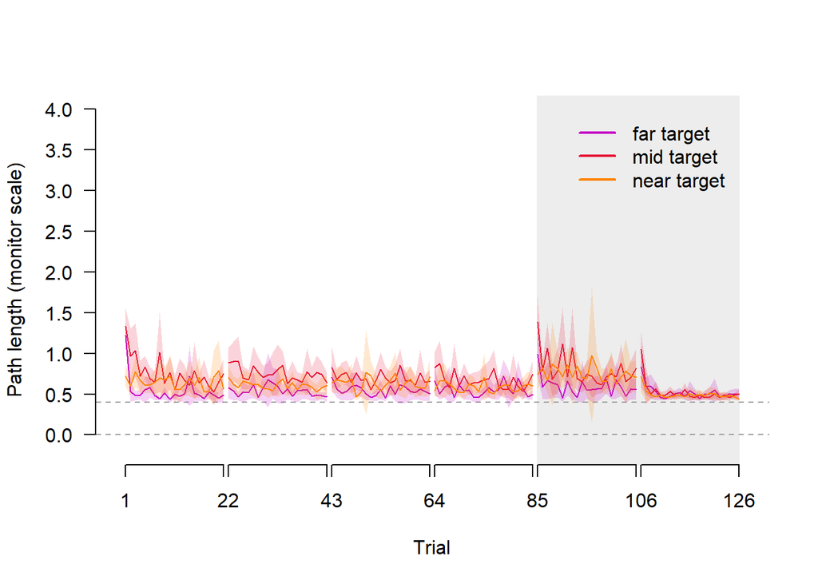

```r
plotCtrlGenPL()
```

##### Learned performance

We first tested for target or block effects for path length within each quadrant. Thus, we conducted 3x3 (target x block) within-subjects ANOVA for quadrants 1, 4, 2, top-up trials in quadrant 1 (Quadrant 1A in tests below), quadrant 1 after switching hands (Quadrant 1L in tests below), and washout (Quadrant 1W).

```r
pathlengthANOVA()
```

```
## Quadrant 1:
## $ANOVA
##         Effect DFn DFd        F            p p<.05        ges
## 2        block   2  94 27.31672 4.441516e-10     * 0.08165414
## 3       target   2  94 18.90872 1.253963e-07     * 0.07077614
## 4 block:target   4 188  5.85361 1.842852e-04     * 0.04418483
##
## $`Mauchly's Test for Sphericity`
##         Effect         W            p p<.05
## 2        block 0.9907862 8.082378e-01
## 3       target 0.9148337 1.290830e-01
## 4 block:target 0.3787548 1.383598e-06     *
##
## $`Sphericity Corrections`
##         Effect       GGe        p[GG] p[GG]<.05       HFe        p[HF]
## 2        block 0.9908704 5.237882e-10         * 1.0342865 4.441516e-10
## 3       target 0.9215177 3.387851e-07         * 0.9573905 2.150488e-07
## 4 block:target 0.7078015 1.103567e-03         * 0.7578761 8.104160e-04
##   p[HF]<.05
## 2         *
## 3         *
## 4         *
##
## Quadrant 4:
## $ANOVA
##         Effect DFn DFd         F            p p<.05        ges
## 2        block   2  94  6.056626 3.356115e-03     * 0.02008565
## 3       target   2  94 31.543716 3.298841e-11     * 0.13096988
## 4 block:target   4 188  2.356535 5.523542e-02       0.01472088
##
## $`Mauchly's Test for Sphericity`
##         Effect         W            p p<.05
## 2        block 0.9404363 2.435431e-01
## 3       target 0.8998320 8.824968e-02
## 4 block:target 0.4295296 1.512285e-05     *
##
## $`Sphericity Corrections`
##         Effect       GGe        p[GG] p[GG]<.05       HFe        p[HF]
## 2        block 0.9437847 4.038162e-03         * 0.9820279 3.560454e-03
## 3       target 0.9089521 2.151055e-10         * 0.9435087 1.055497e-10
```

[output cut: 82 more lines]

```
## $`Mauchly's Test for Sphericity`
##         Effect          W            p p<.05
## 2        block 0.24032861 5.734902e-15     *
## 3       target 0.70284587 3.004569e-04     *
## 4 block:target 0.05300854 2.783536e-24     *
##
## $`Sphericity Corrections`
##         Effect       GGe        p[GG] p[GG]<.05       HFe        p[HF]
## 2        block 0.5682879 7.932101e-09         * 0.5729581 7.006979e-09
## 3       target 0.7709184 3.285060e-03         * 0.7920268 3.008534e-03
## 4 block:target 0.5384969 1.956740e-02         * 0.5652198 1.785954e-02
##   p[HF]<.05
## 2         *
## 3         *
## 4         *
```

```r
pathlengthBayesANOVA()
```

```
## Quadrant 1:
## Bayes factor analysis
## --------------
## [1] target + participant                        : 182587.9     ±0.8%
## [2] block + participant                         : 3011234      ±0.6%
## [3] target + block + participant                : 3.043341e+12 ±2.6%
## [4] target + block + target:block + participant : 6.781955e+14 ±1.81%
##
## Against denominator:
##   pathlength ~ participant
## ---
## Bayes factor type: BFlinearModel, JZS
##
## Inclusion Bayes Factors (Model Averaged)
##
##              P(prior) P(posterior) Inclusion BF
## participant      1.00         1.00
## target           0.60         1.00     1.51e+08
## block            0.60         1.00     2.49e+09
## block:target     0.20         1.00       891.38
##
## * Compared among: all models
## *    Priors odds: uniform-equalQuadrant 4:
## Bayes factor analysis
## --------------
## [1] target + participant                        : 5.184025e+13 ±0.69%
## [2] block + participant                         : 1.929986     ±0.75%
## [3] target + block + participant                : 2.422803e+14 ±1.25%
## [4] target + block + target:block + participant : 7.16678e+13  ±1.18%
##
## Against denominator:
##   pathlength ~ participant
## ---
## Bayes factor type: BFlinearModel, JZS
##
## Inclusion Bayes Factors (Model Averaged)
##
##              P(prior) P(posterior) Inclusion BF
## participant      1.00         1.00
## target           0.60         1.00     8.32e+13
```

[output cut: 78 more lines]

```
## Against denominator:
##   pathlength ~ participant
## ---
## Bayes factor type: BFlinearModel, JZS
##
## Inclusion Bayes Factors (Model Averaged)
##
##              P(prior) P(posterior) Inclusion BF
## participant      1.00         1.00
## target           0.60         0.99       129.35
## block            0.60         1.00     2.93e+14
## block:target     0.20         0.87        25.71
##
## * Compared among: all models
## *    Priors odds: uniform-equal
```

In quadrants 1, top-up trials to quadrant 1 (1A), reaches to quadrant 1 after switching hands (1L), and washout (1W), we find significant target x block interactions. We know from the plot that path length decreases across blocks. Thus, it is more interesting to test for target differences across the blocks of trials.

```r
#Quadrant 1
quadrant1PLComparisonsEffSize()
```

```
##  contrast                 estimate     SE df t.ratio p.value
##  1st block: Far vs. Mid     0.3210 0.1045 47   3.070  0.0319
##  1st block: Far vs. Near   -0.1055 0.0719 47  -1.468  1.0000
##  1st block: Mid vs. Near   -0.4265 0.0792 47  -5.386  <.0001
##  2nd block: Far vs. Mid     0.2072 0.0452 47   4.587  0.0003
##  2nd block: Far vs. Near    0.0885 0.0414 47   2.140  0.3378
##  2nd block: Mid vs. Near   -0.1187 0.0467 47  -2.544  0.1288
##  last block: Far vs. Mid    0.1934 0.0445 47   4.347  0.0007
##  last block: Far vs. Near   0.2172 0.0847 47   2.563  0.1228
##  last block: Mid vs. Near   0.0238 0.0775 47   0.306  1.0000
##
## P value adjustment: bonferroni method for 9 tests
##                   contrast  etasquared
## 1   1st block: Far vs. Mid 0.167076704
## 2  1st block: Far vs. Near 0.043832396
## 3  1st block: Mid vs. Near 0.381671425
## 4   2nd block: Far vs. Mid 0.309273147
## 5  2nd block: Far vs. Near 0.088824194
## 6  2nd block: Mid vs. Near 0.121031904
## 7  last block: Far vs. Mid 0.286725012
## 8 last block: Far vs. Near 0.122602734
## 9 last block: Mid vs. Near 0.001994775
```

```r
quadrant1PLComparisonsBayesfollowup()
```

```
## Bayesian t-test block 1 far vs mid target:
## Bayes factor analysis
## --------------
## [1] Alt., r=0.707 : 12.60603 ±0%
##
## Against denominator:
##   Null, mu1-mu2 = 0
## ---
## Bayes factor type: BFindepSample, JZS
##
## Bayesian t-test block 1 far vs near target:
## Bayes factor analysis
## --------------
## [1] Alt., r=0.707 : 0.5555968 ±0.02%
##
## Against denominator:
##   Null, mu1-mu2 = 0
## ---
## Bayes factor type: BFindepSample, JZS
##
## Bayesian t-test  block 1 mid vs near target:
## Bayes factor analysis
## --------------
## [1] Alt., r=0.707 : 1299.058 ±0%
##
## Against denominator:
##   Null, mu1-mu2 = 0
## ---
## Bayes factor type: BFindepSample, JZS
##
## Bayesian t-test block 2 far vs mid target:
## Bayes factor analysis
## --------------
## [1] Alt., r=0.707 : 124.5808 ±0%
##
## Against denominator:
##   Null, mu1-mu2 = 0
## ---
## Bayes factor type: BFindepSample, JZS
##
```

[output cut: 34 more lines]

```
##
## Against denominator:
##   Null, mu1-mu2 = 0
## ---
## Bayes factor type: BFindepSample, JZS
##
## Bayesian t-test last block mid vs near target:
## Bayes factor analysis
## --------------
## [1] Alt., r=0.707 : 0.2205006 ±0.02%
##
## Against denominator:
##   Null, mu1-mu2 = 0
## ---
## Bayes factor type: BFindepSample, JZS
```

```r
#Quadrant 1A
quadrant1APLComparisonsEffSize()
```

```
##  contrast                 estimate     SE df t.ratio p.value
##  1st block: Far vs. Mid     0.2005 0.0500 47   4.010  0.0019
##  1st block: Far vs. Near    0.0268 0.0357 47   0.749  1.0000
##  1st block: Mid vs. Near   -0.1737 0.0544 47  -3.196  0.0224
##  2nd block: Far vs. Mid     0.0884 0.0479 47   1.848  0.6379
##  2nd block: Far vs. Near    0.0159 0.0303 47   0.524  1.0000
##  2nd block: Mid vs. Near   -0.0726 0.0401 47  -1.808  0.6927
##  last block: Far vs. Mid    0.1186 0.0347 47   3.416  0.0119
##  last block: Far vs. Near   0.0961 0.0340 47   2.827  0.0619
##  last block: Mid vs. Near  -0.0225 0.0336 47  -0.671  1.0000
##
## P value adjustment: bonferroni method for 9 tests
##                   contrast  etasquared
## 1   1st block: Far vs. Mid 0.254928590
## 2  1st block: Far vs. Near 0.011795225
## 3  1st block: Mid vs. Near 0.178509271
## 4   2nd block: Far vs. Mid 0.067749147
## 5  2nd block: Far vs. Near 0.005805544
## 6  2nd block: Mid vs. Near 0.065046002
## 7  last block: Far vs. Mid 0.198902991
## 8 last block: Far vs. Near 0.145333615
## 9 last block: Mid vs. Near 0.009490253
```

```r
quadrant1APLComparisonsBayesfollowup()
```

```
## Bayesian t-test block 1 far vs mid target:
## Bayes factor analysis
## --------------
## [1] Alt., r=0.707 : 7.197919 ±0%
##
## Against denominator:
##   Null, mu1-mu2 = 0
## ---
## Bayes factor type: BFindepSample, JZS
##
## Bayesian t-test block 1 far vs near target:
## Bayes factor analysis
## --------------
## [1] Alt., r=0.707 : 0.237635 ±0.02%
##
## Against denominator:
##   Null, mu1-mu2 = 0
## ---
## Bayes factor type: BFindepSample, JZS
##
## Bayesian t-test  block 1 mid vs near target:
## Bayes factor analysis
## --------------
## [1] Alt., r=0.707 : 2.463432 ±0.01%
##
## Against denominator:
##   Null, mu1-mu2 = 0
## ---
## Bayes factor type: BFindepSample, JZS
##
## Bayesian t-test block 2 far vs mid target:
## Bayes factor analysis
## --------------
## [1] Alt., r=0.707 : 0.7020362 ±0.02%
##
## Against denominator:
##   Null, mu1-mu2 = 0
## ---
## Bayes factor type: BFindepSample, JZS
##
```

[output cut: 34 more lines]

```
##
## Against denominator:
##   Null, mu1-mu2 = 0
## ---
## Bayes factor type: BFindepSample, JZS
##
## Bayesian t-test last block mid vs near target:
## Bayes factor analysis
## --------------
## [1] Alt., r=0.707 : 0.2382996 ±0.02%
##
## Against denominator:
##   Null, mu1-mu2 = 0
## ---
## Bayes factor type: BFindepSample, JZS
```

```r
#Quadrant 1L
quadrant1LPLComparisonsEffSize()
```

```
##  contrast                 estimate     SE df t.ratio p.value
##  1st block: Far vs. Mid    0.33086 0.0747 47   4.430  0.0005
##  1st block: Far vs. Near  -0.00818 0.0687 47  -0.119  1.0000
##  1st block: Mid vs. Near  -0.33904 0.0736 47  -4.606  0.0003
##  2nd block: Far vs. Mid    0.31193 0.1155 47   2.702  0.0861
##  2nd block: Far vs. Near   0.19515 0.0816 47   2.391  0.1879
##  2nd block: Mid vs. Near  -0.11679 0.1245 47  -0.938  1.0000
##  last block: Far vs. Mid   0.17452 0.0545 47   3.200  0.0222
##  last block: Far vs. Near  0.19729 0.0741 47   2.663  0.0952
##  last block: Mid vs. Near  0.02277 0.0663 47   0.343  1.0000
##
## P value adjustment: bonferroni method for 9 tests
##                   contrast   etasquared
## 1   1st block: Far vs. Mid 0.2945665889
## 2  1st block: Far vs. Near 0.0003022933
## 3  1st block: Mid vs. Near 0.3110508098
## 4   2nd block: Far vs. Mid 0.1344393459
## 5  2nd block: Far vs. Near 0.1084217702
## 6  2nd block: Mid vs. Near 0.0183858065
## 7  last block: Far vs. Mid 0.1788635096
## 8 last block: Far vs. Near 0.1310802914
## 9 last block: Mid vs. Near 0.0025041143
```

```r
quadrant1LPLComparisonsBayesfollowup()
```

```
## Bayesian t-test block 1 far vs mid target:
## Bayes factor analysis
## --------------
## [1] Alt., r=0.707 : 17.45402 ±0%
##
## Against denominator:
##   Null, mu1-mu2 = 0
## ---
## Bayes factor type: BFindepSample, JZS
##
## Bayesian t-test block 1 far vs near target:
## Bayes factor analysis
## --------------
## [1] Alt., r=0.707 : 0.2155901 ±0.02%
##
## Against denominator:
##   Null, mu1-mu2 = 0
## ---
## Bayes factor type: BFindepSample, JZS
##
## Bayesian t-test  block 1 mid vs near target:
## Bayes factor analysis
## --------------
## [1] Alt., r=0.707 : 94.64334 ±0%
##
## Against denominator:
##   Null, mu1-mu2 = 0
## ---
## Bayes factor type: BFindepSample, JZS
##
## Bayesian t-test block 2 far vs mid target:
## Bayes factor analysis
## --------------
## [1] Alt., r=0.707 : 4.442139 ±0.01%
##
## Against denominator:
##   Null, mu1-mu2 = 0
## ---
## Bayes factor type: BFindepSample, JZS
##
```

[output cut: 34 more lines]

```
##
## Against denominator:
##   Null, mu1-mu2 = 0
## ---
## Bayes factor type: BFindepSample, JZS
##
## Bayesian t-test last block mid vs near target:
## Bayes factor analysis
## --------------
## [1] Alt., r=0.707 : 0.2218428 ±0.02%
##
## Against denominator:
##   Null, mu1-mu2 = 0
## ---
## Bayes factor type: BFindepSample, JZS
```

```r
#Quadrant 1W
quadrant1WPLComparisonsEffSize()
```

```
##  contrast                 estimate     SE df t.ratio p.value
##  1st block: Far vs. Mid    0.16054 0.0730 47   2.200  0.2946
##  1st block: Far vs. Near  -0.05358 0.0539 47  -0.994  1.0000
##  1st block: Mid vs. Near  -0.21412 0.0745 47  -2.874  0.0547
##  2nd block: Far vs. Mid    0.03874 0.0250 47   1.549  1.0000
##  2nd block: Far vs. Near  -0.00342 0.0162 47  -0.211  1.0000
##  2nd block: Mid vs. Near  -0.04216 0.0181 47  -2.332  0.2161
##  last block: Far vs. Mid  -0.01807 0.0176 47  -1.028  1.0000
##  last block: Far vs. Near -0.03576 0.0170 47  -2.098  0.3719
##  last block: Mid vs. Near -0.01769 0.0119 47  -1.489  1.0000
##
## P value adjustment: bonferroni method for 9 tests
##                   contrast   etasquared
## 1   1st block: Far vs. Mid 0.0933863452
## 2  1st block: Far vs. Near 0.0205803151
## 3  1st block: Mid vs. Near 0.1494322489
## 4   2nd block: Far vs. Mid 0.0485636141
## 5  2nd block: Far vs. Near 0.0009453199
## 6  2nd block: Mid vs. Near 0.1037392704
## 7  last block: Far vs. Mid 0.0219776261
## 8 last block: Far vs. Near 0.0856211284
## 9 last block: Mid vs. Near 0.0450396887
```

```r
quadrant1WPLComparisonsBayesfollowup()
```

```
## Bayesian t-test block 1 far vs mid target:
## Bayes factor analysis
## --------------
## [1] Alt., r=0.707 : 1.412268 ±0.01%
##
## Against denominator:
##   Null, mu1-mu2 = 0
## ---
## Bayes factor type: BFindepSample, JZS
##
## Bayesian t-test block 1 far vs near target:
## Bayes factor analysis
## --------------
## [1] Alt., r=0.707 : 0.313237 ±0.02%
##
## Against denominator:
##   Null, mu1-mu2 = 0
## ---
## Bayes factor type: BFindepSample, JZS
##
## Bayesian t-test  block 1 mid vs near target:
## Bayes factor analysis
## --------------
## [1] Alt., r=0.707 : 6.127847 ±0%
##
## Against denominator:
##   Null, mu1-mu2 = 0
## ---
## Bayes factor type: BFindepSample, JZS
##
## Bayesian t-test block 2 far vs mid target:
## Bayes factor analysis
## --------------
## [1] Alt., r=0.707 : 0.7192991 ±0.02%
##
## Against denominator:
##   Null, mu1-mu2 = 0
## ---
## Bayes factor type: BFindepSample, JZS
##
```

[output cut: 34 more lines]

```
##
## Against denominator:
##   Null, mu1-mu2 = 0
## ---
## Bayes factor type: BFindepSample, JZS
##
## Bayesian t-test last block mid vs near target:
## Bayes factor analysis
## --------------
## [1] Alt., r=0.707 : 0.4352399 ±0.02%
##
## Against denominator:
##   Null, mu1-mu2 = 0
## ---
## Bayes factor type: BFindepSample, JZS
```

In quadrant 1, follow-up tests show that the path length for the far target is shorter compared to the middle target in all blocks, and that the middle target has a longer path length than near target in the first block.

In quadrant 1A (top-up trials), we find shorter path lengths for the far target compared to the middle target in the first and last block, while the path lengths for the middle target were longer that the near target in the first block.

In quadrant 1L (switch to nondominant hand), we find similar results as in quadrant 1A.

In quadrant 1W (washout trials), follow up frequentist tests did not show any significant results. But, Bayesian tests show that the middle target is different than the near target in the first block.

Taken together, it seems that movement trajectories were shortest for the far target and longest for the middle target.

For quadrant 4, we observe main effects of target and block. For quadrant 2, we observe a main effect of target. We conduct follow-up tests on the target effect.

```r
#quadrant 4
quadrant4PLComparisonsEffSizeTargetEffect()
```

```
##  contrast     estimate     SE df t.ratio p.value
##  Far vs. Mid    0.2635 0.0366 47   7.195  <.0001
##  Far vs. Near   0.0953 0.0278 47   3.426  0.0038
##  Mid vs. Near  -0.1682 0.0357 47  -4.718  0.0001
##
## P value adjustment: bonferroni method for 3 tests
##       contrast etasquared
## 1  Far vs. Mid  0.5241158
## 2 Far vs. Near  0.1998185
## 3 Mid vs. Near  0.3214198
```

```r
quadrant4PLComparisonsTargetEffectBayesfollowup()
```

```
## Bayesian t-test far vs mid target:
## Bayes factor analysis
## --------------
## [1] Alt., r=0.707 : 154071.5 ±0%
##
## Against denominator:
##   Null, mu1-mu2 = 0
## ---
## Bayes factor type: BFindepSample, JZS
##
## Bayesian t-test far vs near target:
## Bayes factor analysis
## --------------
## [1] Alt., r=0.707 : 7.410766 ±0%
##
## Against denominator:
##   Null, mu1-mu2 = 0
## ---
## Bayes factor type: BFindepSample, JZS
##
## Bayesian t-test mid vs near target:
## Bayes factor analysis
## --------------
## [1] Alt., r=0.707 : 39.19806 ±0%
##
## Against denominator:
##   Null, mu1-mu2 = 0
## ---
## Bayes factor type: BFindepSample, JZS
```

```r
#quadrant 2
quadrant2PLComparisonsEffSizeTargetEffect()
```

```
##  contrast     estimate     SE df t.ratio p.value
##  Far vs. Mid    0.1418 0.0316 47   4.490  0.0001
##  Far vs. Near   0.0546 0.0370 47   1.476  0.4399
##  Mid vs. Near  -0.0872 0.0300 47  -2.905  0.0168
##
## P value adjustment: bonferroni method for 3 tests
##       contrast etasquared
## 1  Far vs. Mid  0.3001642
## 2 Far vs. Near  0.0442951
## 3 Mid vs. Near  0.1521891
```

```r
quadrant2PLComparisonsTargetEffectBayesfollowup()
```

```
## Bayesian t-test far vs mid target:
## Bayes factor analysis
## --------------
## [1] Alt., r=0.707 : 28.6531 ±0%
##
## Against denominator:
##   Null, mu1-mu2 = 0
## ---
## Bayes factor type: BFindepSample, JZS
##
## Bayesian t-test far vs near target:
## Bayes factor analysis
## --------------
## [1] Alt., r=0.707 : 0.4193616 ±0.02%
##
## Against denominator:
##   Null, mu1-mu2 = 0
## ---
## Bayes factor type: BFindepSample, JZS
##
## Bayesian t-test mid vs near target:
## Bayes factor analysis
## --------------
## [1] Alt., r=0.707 : 0.8460889 ±0.01%
##
## Against denominator:
##   Null, mu1-mu2 = 0
## ---
## Bayes factor type: BFindepSample, JZS
```

In both quadrants, the target effect is accounted for by shorter path lengths for the far and near targets, compared to the middle target. Thus, path lengths support findings for completion times, where movements are faster and shorter for the far target, and slower and longer for the middle target.

##### Retention

To quantify retention, we compare the path lengths between the last block of mirror reversed reaches in session 1, with the first block of mirror reversed reaches in session 2.

```r
retentionPLANOVA()
```

```
## Comparing path length between part 1 and part 2 during learning, trained hand:
## $ANOVA
##           Effect DFn DFd         F            p p<.05        ges
## 2         target   2  94 18.189190 2.100616e-07     * 0.10646047
## 3        session   1  47 29.027428 2.242838e-06     * 0.06512149
## 4 target:session   2  94  9.932946 1.220415e-04     * 0.04565246
##
## $`Mauchly's Test for Sphericity`
##           Effect         W            p p<.05
## 2         target 0.9090956 0.1116912797
## 4 target:session 0.7201432 0.0005255741     *
##
## $`Sphericity Corrections`
##           Effect       GGe        p[GG] p[GG]<.05       HFe        p[HF]
## 2         target 0.9166706 5.793392e-07         * 0.9520338 3.765784e-07
## 4 target:session 0.7813374 4.788498e-04         * 0.8033967 4.169628e-04
##   p[HF]<.05
## 2         *
## 4         *
```

```r
retentionPLBayesANOVA()
```

```
## Comparing path lengths between part 1 and part 2 during learning, trained hand:
## Bayes factor analysis
## --------------
## [1] target + participant                            : 503356.9     ±0.63%
## [2] session + participant                           : 1962.489     ±1.24%
## [3] target + session + participant                  : 4286577090   ±4.14%
## [4] target + session + target:session + participant : 542752344953 ±8%
##
## Against denominator:
##   pathlength ~ participant
## ---
## Bayes factor type: BFlinearModel, JZS
##
## Inclusion Bayes Factors (Model Averaged)
##
##                P(prior) P(posterior) Inclusion BF
## participant        1.00         1.00
## target             0.60         1.00     1.86e+08
## session            0.60         1.00     7.25e+05
## session:target     0.20         0.99       506.41
##
## * Compared among: all models
## *    Priors odds: uniform-equal
```

We find a significant target x session interaction.

```r
part1and2PLComparisonsEffSize()
```

```
##  contrast               estimate     SE df t.ratio p.value
##  Far: Part 1 vs Part 2    0.2392 0.0566 47   4.228  0.0003
##  Mid: Part 1 vs Part 2    0.3418 0.0758 47   4.510  0.0001
##  Near: Part 1 vs Part 2  -0.0237 0.0422 47  -0.562  1.0000
##
## P value adjustment: bonferroni method for 3 tests
##                 contrast  etasquared
## 1  Far: Part 1 vs Part 2 0.275547535
## 2  Mid: Part 1 vs Part 2 0.302062210
## 3 Near: Part 1 vs Part 2 0.006682688
```

```r
part1and2PLComparisonsBayesfollowup()
```

```
## Bayesian t-test part 1 far vs block 1 far:
## Bayes factor analysis
## --------------
## [1] Alt., r=0.707 : 51.05797 ±0%
##
## Against denominator:
##   Null, mu1-mu2 = 0
## ---
## Bayes factor type: BFindepSample, JZS
##
## Bayesian t-test part 1 mid vs block 1 mid:
## Bayes factor analysis
## --------------
## [1] Alt., r=0.707 : 66.09445 ±0%
##
## Against denominator:
##   Null, mu1-mu2 = 0
## ---
## Bayes factor type: BFindepSample, JZS
##
## Bayesian t-test part 1 near vs block 1 near:
## Bayes factor analysis
## --------------
## [1] Alt., r=0.707 : 0.2353186 ±0.02%
##
## Against denominator:
##   Null, mu1-mu2 = 0
## ---
## Bayes factor type: BFindepSample, JZS
```

Follow-up tests show that the far and middle targets had slightly longer path lengths for the first block in session 2, compared to the last block in session 1. However, in comparing path length plots, we see that the starting path lengths in session 2 are shorter than how participants started in session 1, suggesting that there was retention of learning.

##### Generalization across the workspace and hands

To quantify generalization, we compare path length across quadrants. We conduct a 3x3x2 (target x block x quadrant) within-subjects ANOVA to compare the first set of reaches to quadrant 1 with reaches in quadrant 4. We repeat this test but instead compare quadrant 1 with quadrant 2, quadrant 1 and reaches to quadrant 1 after switching hands (Quadrant 1L).

```r
#Quadrant 1 vs Quadrant 4
PLANOVA2Quads(quadrantA= '1', quadrantB = '4')
```

```
## Quadrants 1 and 4:
## $ANOVA
##                  Effect DFn DFd          F            p p<.05          ges
## 2                target   2  94 45.1194287 1.836924e-14     * 0.0936102625
## 3                 block   2  94 29.9560713 8.613578e-11     * 0.0472125883
## 4              quadrant   1  47  8.1495336 6.390070e-03     * 0.0090243153
## 5          target:block   4 188  7.3758953 1.539295e-05     * 0.0244977684
## 6       target:quadrant   2  94  0.1774823 8.376558e-01       0.0003575667
## 7        block:quadrant   2  94  8.5839316 3.766899e-04     * 0.0139527356
## 8 target:block:quadrant   4 188  2.4459802 4.796576e-02     * 0.0094940932
##
## $`Mauchly's Test for Sphericity`
##                  Effect         W            p p<.05
## 2                target 0.8991779 8.678600e-02
## 3                 block 0.9935590 8.618956e-01
## 5          target:block 0.6680599 3.175772e-02     *
## 6       target:quadrant 0.8965993 8.123869e-02
## 7        block:quadrant 0.9286346 1.821511e-01
## 8 target:block:quadrant 0.2734334 2.276590e-09     *
##
## $`Sphericity Corrections`
##                  Effect       GGe        p[GG] p[GG]<.05       HFe        p[HF]
## 2                target 0.9084120 2.364596e-13         * 0.9429124 9.028390e-14
## 3                 block 0.9936003 9.767824e-11         * 1.0373230 8.613578e-11
## 5          target:block 0.8225118 6.827605e-05         * 0.8918007 3.812063e-05
## 6       target:quadrant 0.9062891 8.167966e-01           0.9405687 8.247816e-01
## 7        block:quadrant 0.9333884 5.332096e-04         * 0.9705188 4.392711e-04
## 8 target:block:quadrant 0.6698903 7.377831e-02           0.7142243 6.960860e-02
##   p[HF]<.05
## 2         *
## 3         *
## 5         *
## 6
## 7         *
## 8
```

```r
PLBayesANOVA2Quads(quadrantA= '1', quadrantB = '4')
```

```
## Quadrants 1 and 4:
## Bayes factor analysis
## --------------
## [1] target + participant                                                                                               : 5.279844e+17 ±0.7%
## [2] block + participant                                                                                                : 16017996     ±0.67%
## [3] target + block + participant                                                                                       : 1.086243e+26 ±1.94%
## [4] target + block + target:block + participant                                                                        : 3.163087e+28 ±1.49%
## [5] quadrant + participant                                                                                             : 3.589982     ±6.14%
## [6] target + quadrant + participant                                                                                    : 2.799733e+18 ±1.18%
## [7] block + quadrant + participant                                                                                     : 67279323     ±1.67%
## [8] target + block + quadrant + participant                                                                            : 7.813205e+26 ±2.32%
## [9] target + block + target:block + quadrant + participant                                                             : 2.507852e+29 ±3.42%
## [10] target + quadrant + target:quadrant + participant                                                                 : 8.557373e+16 ±1.96%
## [11] target + block + quadrant + target:quadrant + participant                                                         : 2.225861e+25 ±2.04%
## [12] target + block + target:block + quadrant + target:quadrant + participant                                          : 7.933845e+27 ±3.79%
## [13] block + quadrant + block:quadrant + participant                                                                   : 715149781    ±1.89%
## [14] target + block + quadrant + block:quadrant + participant                                                          : 1.733864e+28 ±2.88%
## [15] target + block + target:block + quadrant + block:quadrant + participant                                           : 7.664109e+30 ±12.34%
## [16] target + block + quadrant + target:quadrant + block:quadrant + participant                                        : 5.503296e+26 ±8.33%
## [17] target + block + target:block + quadrant + target:quadrant + block:quadrant + participant                         : 2.169682e+29 ±2.75%
## [18] target + block + target:block + quadrant + target:quadrant + block:quadrant + target:block:quadrant + participant : 1.415804e+29 ±2.42%
##
## Against denominator:
##   pathlength ~ participant
## ---
## Bayes factor type: BFlinearModel, JZS
##
## Inclusion Bayes Factors (Model Averaged)
##
##                       P(prior) P(posterior) Inclusion BF
## participant               1.00         1.00
## target                    0.74         1.00     3.73e+21
## block                     0.74         1.00     8.72e+11
## block:target              0.32         1.00       958.00
## quadrant                  0.74         1.00        93.40
## quadrant:target           0.32         0.04        0.100
## block:quadrant            0.32         0.97        59.81
## block:quadrant:target     0.05         0.02        0.311
##
## * Compared among: all models
## *    Priors odds: uniform-equal
```

```r
#Quadrant 1 vs Quadrant 2
PLANOVA2Quads(quadrantA= '1', quadrantB = '2')
```

```
## Quadrants 1 and 2:
## $ANOVA
##                  Effect DFn DFd         F            p p<.05         ges
## 2                target   2  94 23.420507 5.581352e-09     * 0.055285548
## 3                 block   2  94 24.552843 2.637153e-09     * 0.037450330
## 4              quadrant   1  47  7.208682 9.991124e-03     * 0.008982951
## 5          target:block   4 188  3.836525 5.067925e-03     * 0.015143355
## 6       target:quadrant   2  94  2.659401 7.525407e-02       0.004423675
## 7        block:quadrant   2  94 10.904214 5.510884e-05     * 0.018500573
## 8 target:block:quadrant   4 188  4.728479 1.170949e-03     * 0.013767298
##
## $`Mauchly's Test for Sphericity`
##                  Effect         W            p p<.05
## 2                target 0.9354853 0.2156998944
## 3                 block 0.9679733 0.4729961578
## 5          target:block 0.6002782 0.0058425106     *
## 6       target:quadrant 0.8971331 0.0823584881
## 7        block:quadrant 0.9861812 0.7261135536
## 8 target:block:quadrant 0.4843176 0.0001391832     *
##
## $`Sphericity Corrections`
##                  Effect       GGe        p[GG] p[GG]<.05       HFe        p[HF]
## 2                target 0.9393952 1.439677e-08         * 0.9771673 7.974919e-09
## 3                 block 0.9689672 4.380336e-09         * 1.0099498 2.637153e-09
## 5          target:block 0.7921080 9.777978e-03         * 0.8560310 7.981184e-03
## 6       target:quadrant 0.9067277 8.099805e-02           0.9410530 7.883984e-02
## 7        block:quadrant 0.9863696 6.058987e-05         * 1.0292818 5.510884e-05
## 8 target:block:quadrant 0.7627273 3.365584e-03         * 0.8216532 2.585680e-03
##   p[HF]<.05
## 2         *
## 3         *
## 5         *
## 6
## 7         *
## 8         *
```

```r
PLBayesANOVA2Quads(quadrantA= '1', quadrantB = '2')
```

```
## Quadrants 1 and 2:
## Bayes factor analysis
## --------------
## [1] target + participant                                                                                               : 5857739217   ±2.7%
## [2] block + participant                                                                                                : 570070.6     ±1.13%
## [3] target + block + participant                                                                                       : 1.105972e+16 ±1.14%
## [4] target + block + target:block + participant                                                                        : 4.04242e+16  ±1.28%
## [5] quadrant + participant                                                                                             : 4.523244     ±1.41%
## [6] target + quadrant + participant                                                                                    : 33008010379  ±1.16%
## [7] block + quadrant + participant                                                                                     : 3228306      ±5.07%
## [8] target + block + quadrant + participant                                                                            : 8.108986e+16 ±1.82%
## [9] target + block + target:block + quadrant + participant                                                             : 3.234835e+17 ±2.58%
## [10] target + quadrant + target:quadrant + participant                                                                 : 6911065179   ±2.66%
## [11] target + block + quadrant + target:quadrant + participant                                                         : 1.816592e+16 ±3.1%
## [12] target + block + target:block + quadrant + target:quadrant + participant                                          : 7.461148e+16 ±2.69%
## [13] block + quadrant + block:quadrant + participant                                                                   : 417624515    ±1.34%
## [14] target + block + quadrant + block:quadrant + participant                                                          : 2.169814e+19 ±2.74%
## [15] target + block + target:block + quadrant + block:quadrant + participant                                           : 1.006458e+20 ±3.21%
## [16] target + block + quadrant + target:quadrant + block:quadrant + participant                                        : 5.071197e+18 ±2.84%
## [17] target + block + target:block + quadrant + target:quadrant + block:quadrant + participant                         : 2.394282e+19 ±2.37%
## [18] target + block + target:block + quadrant + target:quadrant + block:quadrant + target:block:quadrant + participant : 1.343969e+20 ±5.82%
##
## Against denominator:
##   pathlength ~ participant
## ---
## Bayes factor type: BFlinearModel, JZS
##
## Inclusion Bayes Factors (Model Averaged)
##
##                       P(prior) P(posterior) Inclusion BF
## participant               1.00         1.00
## target                    0.74         1.00     2.43e+11
## block                     0.74         1.00     2.23e+09
## block:target              0.32         0.91        20.91
## quadrant                  0.74         1.00     1.99e+03
## quadrant:target           0.32         0.57         2.88
## block:quadrant            0.32         1.00     1.13e+03
## block:quadrant:target     0.05         0.47        15.93
##
## * Compared among: all models
## *    Priors odds: uniform-equal
```

```r
#Quadrant 1 vs Switch hands, Quadrant 1
PLANOVA2Quads(quadrantA= '1', quadrantB = '1L')
```

```
## Quadrants 1 and 1L:
## $ANOVA
##                  Effect DFn DFd          F            p p<.05          ges
## 2                target   2  94 24.7897660 2.257668e-09     * 0.0606153494
## 3                 block   2  94 35.2737660 3.726616e-12     * 0.0488760281
## 4              quadrant   1  47  4.1047632 4.845983e-02     * 0.0053485819
## 5          target:block   4 188  7.9240972 6.348866e-06     * 0.0276348466
## 6       target:quadrant   2  94  0.4986625 6.089399e-01       0.0009049771
## 7        block:quadrant   2  94  2.2927179 1.066128e-01       0.0034034534
## 8 target:block:quadrant   4 188  0.3577068 8.384454e-01       0.0012465698
##
## $`Mauchly's Test for Sphericity`
##                  Effect         W            p p<.05
## 2                target 0.9817035 0.6539542960
## 3                 block 0.9910791 0.8137508652
## 5          target:block 0.7791385 0.2538264849
## 6       target:quadrant 0.7293800 0.0007045934     *
## 7        block:quadrant 0.8424460 0.0193850754     *
## 8 target:block:quadrant 0.7182029 0.0902601799
##
## $`Sphericity Corrections`
##                  Effect       GGe        p[GG] p[GG]<.05       HFe        p[HF]
## 2                target 0.9820322 3.036723e-09         * 1.0244607 2.257668e-09
## 3                 block 0.9911580 4.554898e-12         * 1.0346064 3.726616e-12
## 5          target:block 0.8842846 1.842588e-05         * 0.9650921 8.751651e-06
## 6       target:quadrant 0.7870174 5.650900e-01           0.8095994 5.702460e-01
## 7        block:quadrant 0.8638906 1.147656e-01           0.8938539 1.129395e-01
## 8 target:block:quadrant 0.8763852 8.139150e-01           0.9556732 8.301471e-01
##   p[HF]<.05
## 2         *
## 3         *
## 5         *
## 6
## 7
## 8
```

```r
PLBayesANOVA2Quads(quadrantA= '1', quadrantB = '1L')
```

```
## Quadrants 1 and 1L:
## Bayes factor analysis
## --------------
## [1] target + participant                                                                                               : 105430817983 ±0.59%
## [2] block + participant                                                                                                : 202058409    ±0.62%
## [3] target + block + participant                                                                                       : 1.385945e+20 ±1.73%
## [4] target + block + target:block + participant                                                                        : 3.34542e+23  ±1.3%
## [5] quadrant + participant                                                                                             : 0.8427741    ±1.29%
## [6] target + quadrant + participant                                                                                    : 109741659412 ±1.87%
## [7] block + quadrant + participant                                                                                     : 226000067    ±15.43%
## [8] target + block + quadrant + participant                                                                            : 1.669946e+20 ±1.73%
## [9] target + block + target:block + quadrant + participant                                                             : 4.657503e+23 ±2.91%
## [10] target + quadrant + target:quadrant + participant                                                                 : 4257781222   ±1.8%
## [11] target + block + quadrant + target:quadrant + participant                                                         : 2.238947e+19 ±70.3%
## [12] target + block + target:block + quadrant + target:quadrant + participant                                          : 1.831903e+22 ±2.18%
## [13] block + quadrant + block:quadrant + participant                                                                   : 23995465     ±1.85%
## [14] target + block + quadrant + block:quadrant + participant                                                          : 2.448119e+19 ±7.05%
## [15] target + block + target:block + quadrant + block:quadrant + participant                                           : 8.528327e+22 ±26.16%
## [16] target + block + quadrant + target:quadrant + block:quadrant + participant                                        : 8.804225e+17 ±2.35%
## [17] target + block + target:block + quadrant + target:quadrant + block:quadrant + participant                         : 2.79364e+21  ±8.25%
## [18] target + block + target:block + quadrant + target:quadrant + block:quadrant + target:block:quadrant + participant : 5.054072e+19 ±3.51%
##
## Against denominator:
##   pathlength ~ participant
## ---
## Bayes factor type: BFlinearModel, JZS
##
## Inclusion Bayes Factors (Model Averaged)
##
##                       P(prior) P(posterior) Inclusion BF
## participant               1.00         1.00
## target                    0.74         1.00     7.17e+14
## block                     0.74         1.00     1.48e+12
## block:target              0.32         1.00     5.56e+03
## quadrant                  0.74         0.63        0.611
## quadrant:target           0.32         0.02        0.052
## block:quadrant            0.32         0.10        0.233
## block:quadrant:target     0.05     5.57e-05        0.001
##
## * Compared among: all models
## *    Priors odds: uniform-equal
```

In comparing quadrants 1 and 4, We find a significant block x quadrant interaction.

```r
Q1and4PLComparisonsEffSize()
```

```
##  contrast               estimate     SE df t.ratio p.value
##  Q1 vs Q4, first block  -0.17052 0.0362 47  -4.708  0.0001
##  Q1 vs Q4, second block  0.00916 0.0258 47   0.355  1.0000
##  Q1 vs Q4, last block   -0.02582 0.0396 47  -0.652  1.0000
##
## P value adjustment: bonferroni method for 3 tests
##                 contrast  etasquared
## 1  Q1 vs Q4, first block 0.320440221
## 2 Q1 vs Q4, second block 0.002670466
## 3   Q1 vs Q4, last block 0.008963343
```

```r
Q1and4PLComparisonsBayesfollowup()
```

```
## Bayesian t-test Quad 1 vs Quad 4, block 1:
## Bayes factor analysis
## --------------
## [1] Alt., r=0.707 : 34.80642 ±0%
##
## Against denominator:
##   Null, mu1-mu2 = 0
## ---
## Bayes factor type: BFindepSample, JZS
##
## Bayesian t-test Quad 1 vs Quad 4, block 2:
## Bayes factor analysis
## --------------
## [1] Alt., r=0.707 : 0.1343048 ±0.1%
##
## Against denominator:
##   Null, mu1-mu2 = 0
## ---
## Bayes factor type: BFindepSample, JZS
##
## Bayesian t-test Quad 1 vs Quad 4, last block,:
## Bayes factor analysis
## --------------
## [1] Alt., r=0.707 : 0.1590368 ±0.09%
##
## Against denominator:
##   Null, mu1-mu2 = 0
## ---
## Bayes factor type: BFindepSample, JZS
```

Follow-up tests show that the interaction is driven by a difference between quadrants in the first block. This is expected, given that we see longer path lengths in the first few trials in quadrant 1 reaches.

In comparing quadrants 1 and 2, We find a significant target x block x quadrant interaction.

```r
Q1and2PLComparisonsEffSize()
```

```
##  contrast                     estimate     SE df t.ratio p.value
##  Q1 vs Q2, first block, Far   -0.17481 0.0725 47  -2.412  0.1783
##  Q1 vs Q2, second block, Far   0.04102 0.0437 47   0.940  1.0000
##  Q1 vs Q2, last block, Far     0.05633 0.0320 47   1.759  0.7652
##  Q1 vs Q2, first block, Mid   -0.37265 0.0720 47  -5.175  <.0001
##  Q1 vs Q2, second block, Mid  -0.00744 0.0495 47  -0.150  1.0000
##  Q1 vs Q2, last block, Mid     0.00642 0.0507 47   0.127  1.0000
##  Q1 vs Q2, first block, Near  -0.02439 0.0516 47  -0.473  1.0000
##  Q1 vs Q2, second block, Near -0.01080 0.0474 47  -0.228  1.0000
##  Q1 vs Q2, last block, Near   -0.07877 0.0806 47  -0.978  1.0000
##
## P value adjustment: bonferroni method for 9 tests
##                       contrast   etasquared
## 1   Q1 vs Q2, first block, Far 0.1101639253
## 2  Q1 vs Q2, second block, Far 0.0184364558
## 3    Q1 vs Q2, last block, Far 0.0617899003
## 4   Q1 vs Q2, first block, Mid 0.3629994754
## 5  Q1 vs Q2, second block, Mid 0.0004812673
## 6    Q1 vs Q2, last block, Mid 0.0003410922
## 7  Q1 vs Q2, first block, Near 0.0047334875
## 8 Q1 vs Q2, second block, Near 0.0011033106
## 9   Q1 vs Q2, last block, Near 0.0199289480
```

```r
Q1and2PLComparisonsBayesfollowup()
```

```
## Bayesian t-test Quad 1 vs Quad 2, block 1, far target:
## Bayes factor analysis
## --------------
## [1] Alt., r=0.707 : 2.645761 ±0.01%
##
## Against denominator:
##   Null, mu1-mu2 = 0
## ---
## Bayes factor type: BFindepSample, JZS
##
## Bayesian t-test Quad 1 vs Quad 2, block 2, far target:
## Bayes factor analysis
## --------------
## [1] Alt., r=0.707 : 0.2892594 ±0.02%
##
## Against denominator:
##   Null, mu1-mu2 = 0
## ---
## Bayes factor type: BFindepSample, JZS
##
## Bayesian t-test Quad 1 vs Quad 2, last block, far target:
## Bayes factor analysis
## --------------
## [1] Alt., r=0.707 : 0.5891591 ±0.02%
##
## Against denominator:
##   Null, mu1-mu2 = 0
## ---
## Bayes factor type: BFindepSample, JZS
##
## Bayesian t-test Quad 1 vs Quad 2, block 1, mid target:
## Bayes factor analysis
## --------------
## [1] Alt., r=0.707 : 154.8204 ±0%
##
## Against denominator:
##   Null, mu1-mu2 = 0
## ---
## Bayes factor type: BFindepSample, JZS
##
```

[output cut: 34 more lines]

```
##
## Against denominator:
##   Null, mu1-mu2 = 0
## ---
## Bayes factor type: BFindepSample, JZS
##
## Bayesian t-test Quad 1 vs Quad 2, last block, near target:
## Bayes factor analysis
## --------------
## [1] Alt., r=0.707 : 0.2947548 ±0.02%
##
## Against denominator:
##   Null, mu1-mu2 = 0
## ---
## Bayes factor type: BFindepSample, JZS
```

Follow-up tests show that path lengths differ for the middle target between the two quadrants. We see in the plot that path lengths are longer in the first few trials of reaches in quadrant 1.

Finally, in comparing quadrant 1 with reaches using the nondominant hand, we find a main effect of quadrant but no interactions. From the plot it is evident that path lengths for the nondominant hand are longer on average, compared to those in quadrant 1.

##### Path lengths during washout trials

We have already shown that in washout trials, theere are longer path lengths to the middle target than the near target during the first block. We now compare path lengths with those during the aligned reaches. We conduct a 3x3x2 (target x block x session) within-subjects ANOVA.

```r
RAEUntrainedHandPLANOVA()
```

```
## Comparing path length during washout trials with aligned trials across targets and blocks, untrained hand:
## $ANOVA
##                 Effect DFn DFd         F            p p<.05         ges
## 2                block   2  94 38.924818 4.841993e-13     * 0.072606406
## 3               target   2  94  5.460907 5.705807e-03     * 0.012190707
## 4              session   1  47  8.414360 5.646754e-03     * 0.014015147
## 5         block:target   4 188  3.351437 1.118984e-02     * 0.014117870
## 6        block:session   2  94 23.354652 5.832259e-09     * 0.042798755
## 7       target:session   2  94  4.840212 9.983003e-03     * 0.009994616
## 8 block:target:session   4 188  2.966849 2.086464e-02     * 0.011153314
##
## $`Mauchly's Test for Sphericity`
##                 Effect         W            p p<.05
## 2                block 0.5982875 7.394837e-06     *
## 3               target 0.9653238 4.440988e-01
```

[output cut: 20 more lines]

```r
RAEUntrainedHandPLBayesANOVA()
```

```
## Comparing path lengths during washout trials with aligned trials across targets and blocks, untrained hand:
## Bayes factor analysis
## --------------
## [1] target + participant                                                                                           : 1.585437     ±1.09%
## [2] block + participant                                                                                            : 672425480488 ±0.92%
## [3] target + block + participant                                                                                   : 1.623469e+12 ±1.72%
## [4] target + block + target:block + participant                                                                    : 1.402895e+12 ±2.27%
## [5] session + participant                                                                                          : 20.46651     ±0.96%
## [6] target + session + participant                                                                                 : 35.21818     ±1.63%
## [7] block + session + participant                                                                                  : 2.249889e+13 ±1.55%
## [8] target + block + session + participant                                                                         : 5.518454e+13 ±2.02%
## [9] target + block + target:block + session + participant                                                          : 5.251257e+13 ±2.08%
## [10] target + session + target:session + participant                                                               : 43.50809     ±1.91%
## [11] target + block + session + target:session + participant                                                       : 9.287978e+13 ±3.18%
## [12] target + block + target:block + session + target:session + participant                                        : 9.297706e+13 ±2.46%
## [13] block + session + block:session + participant                                                                 : 9.761565e+19 ±1.63%
## [14] target + block + session + block:session + participant                                                        : 3.132566e+20 ±1.67%
## [15] target + block + target:block + session + block:session + participant                                         : 3.957527e+20 ±2.54%
## [16] target + block + session + target:session + block:session + participant                                       : 6.856838e+20 ±3.66%
## [17] target + block + target:block + session + target:session + block:session + participant                        : 1.109027e+21 ±17.28%
## [18] target + block + target:block + session + target:session + block:session + target:block:session + participant : 7.263394e+20 ±2.79%
##
## Against denominator:
##   pathlength ~ participant
## ---
## Bayes factor type: BFlinearModel, JZS
##
## Inclusion Bayes Factors (Model Averaged)
##
##                      P(prior) P(posterior) Inclusion BF
## participant              1.00         1.00
## target                   0.74         0.97        11.82
## block                    0.74         1.00     1.17e+19
## block:target             0.32         0.67         4.41
## session                  0.74         1.00     3.21e+08
## session:target           0.32         0.76         6.77
## block:session            0.32         1.00     2.25e+07
## block:session:target     0.05         0.22         5.03
##
## * Compared among: all models
## *    Priors odds: uniform-equal
```

We find a main effect of session, and a significant target x block x session interaction. We conduct follow-up tests on the interaction.

```r
untrainedHandSessionPLComparisonsEffSize()
```

```
##  contrast                                          estimate     SE df t.ratio
##  Baseline vs Washout in part 2, first block, Far    0.10901 0.0517 47   2.108
##  Baseline vs Washout in part 2, second block, Far  -0.05528 0.0322 47  -1.715
##  Baseline vs Washout in part 2, last block, Far     0.02476 0.0191 47   1.298
##  Baseline vs Washout in part 2, first block, Mid    0.26889 0.0635 47   4.235
##  Baseline vs Washout in part 2, second block, Mid   0.00391 0.0265 47   0.147
##  Baseline vs Washout in part 2, last block, Mid     0.00858 0.0140 47   0.615
##  Baseline vs Washout in part 2, first block, Near   0.07485 0.0413 47   1.812
##  Baseline vs Washout in part 2, second block, Near -0.01107 0.0144 47  -0.768
##  Baseline vs Washout in part 2, last block, Near   -0.03485 0.0172 47  -2.028
##  p.value
##   0.3632
##   0.8360
##   1.0000
##   0.0010
##   1.0000
##   1.0000
##   0.6877
##   1.0000
##   0.4342
##
## P value adjustment: bonferroni method for 9 tests
##                                            contrast   etasquared
## 1   Baseline vs Washout in part 2, first block, Far 0.0864085979
## 2  Baseline vs Washout in part 2, second block, Far 0.0589090249
## 3    Baseline vs Washout in part 2, last block, Far 0.0346083140
## 4   Baseline vs Washout in part 2, first block, Mid 0.2761811889
## 5  Baseline vs Washout in part 2, second block, Mid 0.0004614064
## 6    Baseline vs Washout in part 2, last block, Mid 0.0079808537
## 7  Baseline vs Washout in part 2, first block, Near 0.0652805394
## 8 Baseline vs Washout in part 2, second block, Near 0.0124026015
## 9   Baseline vs Washout in part 2, last block, Near 0.0804681557
```

```r
untrainedHandSessionPLComparisonsBayesfollowup()
```

```
## Bayesian t-test baseline vs washout in part 2, block 1, far target:
## Bayes factor analysis
## --------------
## [1] Alt., r=0.707 : 1.346249 ±0.01%
##
## Against denominator:
##   Null, mu1-mu2 = 0
## ---
## Bayes factor type: BFindepSample, JZS
##
## Bayesian t-test baseline vs washout in part 2, block 2, far target:
## Bayes factor analysis
## --------------
## [1] Alt., r=0.707 : 0.7490008 ±0.01%
##
## Against denominator:
##   Null, mu1-mu2 = 0
## ---
## Bayes factor type: BFindepSample, JZS
##
## Bayesian t-test baseline vs washout in part 2, last block, far target:
## Bayes factor analysis
## --------------
## [1] Alt., r=0.707 : 0.4671051 ±0.02%
##
## Against denominator:
##   Null, mu1-mu2 = 0
## ---
## Bayes factor type: BFindepSample, JZS
##
## Bayesian t-test baseline vs washout in part 2, block 1, mid target:
## Bayes factor analysis
## --------------
## [1] Alt., r=0.707 : 153.6851 ±0%
##
## Against denominator:
##   Null, mu1-mu2 = 0
## ---
## Bayes factor type: BFindepSample, JZS
##
```

[output cut: 34 more lines]

```
##
## Against denominator:
##   Null, mu1-mu2 = 0
## ---
## Bayes factor type: BFindepSample, JZS
##
## Bayesian t-test baseline vs washout in part 2, last block, near target:
## Bayes factor analysis
## --------------
## [1] Alt., r=0.707 : 0.8876418 ±0.01%
##
## Against denominator:
##   Null, mu1-mu2 = 0
## ---
## Bayes factor type: BFindepSample, JZS
```

Follow-up tests show that the interaction is driven by the longer path lengths for the middle target during the first block of washout compared to the first block of aligned reaches. This confirms what we observe with the plots that path lengths for the middle target are longer during the first few trials of washout.

# Study 2: Supplementary analyses for the online experiment